# Economic Intelligence & Forecasting System

# Kolmogorov-Smirnov (K-S) Test

```python
sample = df_clean["Composite_Risk_Score"].dropna()
stat, p_value = kstest(
    sample,
    'norm',
    args=(
        sample.mean(),
        sample.std()
    )
)

print("KS Statistic:", round(stat,4))
print("P Value:", p_value)
```

```
KS Statistic: 0.1054
P Value: 0.0
```

```python
if p_value < 0.05:
    print("Not Normally Distributed")
else:
    print("Normally Distributed")
```

```
Not Normally Distributed
```

# A/B Testing

```python
control = df_clean[df_clean["AB_Test_Group"]=="Control"]["Composite_Risk_Score"]

treatment = df_clean[df_clean["AB_Test_Group"]=="Treatment"]["Composite_Risk_Score"]
```

```python
print("Control Mean :",round(control.mean(),4))
print("Treatment Mean :",round(treatment.mean(),4))
```

```
Control Mean : 3.9902
Treatment Mean : 3.9886
```

```python
t_stat,p_value = ttest_ind(
    control,
    treatment,
    equal_var=False
)
print("T Statistic :",round(t_stat,4))
print("P Value :",p_value)
```

```
T Statistic : 0.391
P Value : 0.6958210788489351
```

```python
alpha = 0.05
if p_value < alpha:
    print( "Reject Null Hypothesis" )
else:
    print( "Fail to Reject Null Hypothesis" )
```

```
Fail to Reject Null Hypothesis
```

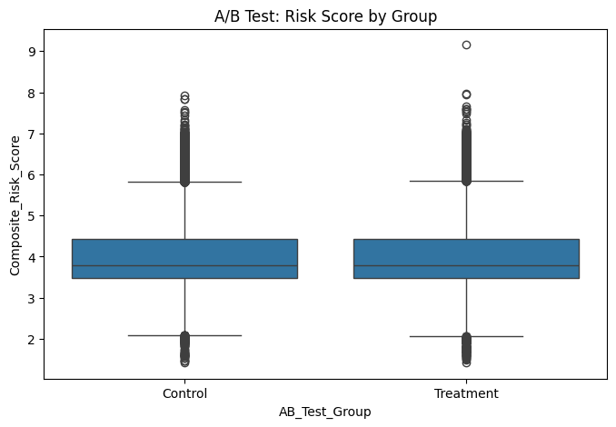

```python
plt.figure(figsize=(8,5))
sns.boxplot(data=df_clean,x="AB_Test_Group", y="Composite_Risk_Score")
plt.title("A/B Test: Risk Score by Group")
plt.show()
```

# Missing Value Treatment

```python
missing_summary = pd.DataFrame({
    "Missing_Count":
    df_clean.isnull().sum(),
    "Missing_%":
    round( df_clean.isnull().mean()*100,2)
})

missing_summary = (
    missing_summary
    [missing_summary["Missing_Count"]>0].sort_values("Missing_Count",ascending=False)
)
missing_summary
```

|  | Missing_Count | Missing_% |
| --- | --- | --- |

```python
df_clean.isnull().sum().sum()
```

```
np.int64(0)
```

```python
df[col].fillna(
    df[col].median(),
    inplace=True
)
```

```
0         3.996
1         3.673
2         3.491
3         4.676
4         5.838
          ...
149995    2.779
149996    3.686
149997    3.741
149998    4.968
149999    2.860
Name: Composite_Risk_Score, Length: 150000, dtype: float64
```

```python
df[col].fillna(
    df[col].mode()[0],
    inplace=True
)
```

```
0         3.996
1         3.673
2         3.491
3         4.676
4         5.838
          ...
149995    2.779
149996    3.686
149997    3.741
149998    4.968
149999    2.860
Name: Composite_Risk_Score, Length: 150000, dtype: float64
```

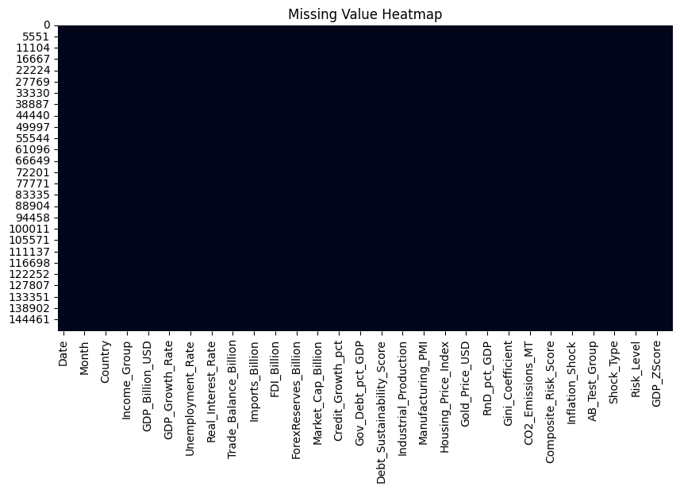

```python
plt.figure(figsize=(10,5))
sns.heatmap( df_clean.isnull(),cbar=False)
plt.title("Missing Value Heatmap")
plt.show()
```

# Feature Engineering

```python
engineered_cols = [
    "Income_Group",
    "Risk_Level",
    "Inflation_Shock",
    "Recession_Flag",
    "AB_Test_Group"
]
df_clean[engineered_cols].head(10)
```

|  | Income_Group | Risk_Level | Inflation_Shock | Recession_Flag | AB_Test_Group |
| --- | --- | --- | --- | --- | --- |
| 0 | Lower-Middle | Medium | 0 | 0 | Control |
| 1 | High | Low | 0 | 0 | Treatment |
| 2 | High | Medium | 0 | 0 | Treatment |
| 3 | Upper-Middle | High | 0 | 0 | Treatment |
| 4 | Upper-Middle | Critical | 0 | 0 | Control |
| 5 | High | Critical | 0 | 1 | Control |
| 6 | High | Critical | 0 | 1 | Control |
| 7 | High | Medium | 0 | 0 | Treatment |
| 8 | High | Medium | 0 | 0 | Treatment |
| 9 | Upper-Middle | Medium | 0 | 0 | Treatment |

```python
feature_summary = pd.DataFrame({
    "Unique_Count":df_clean.nunique(),
    "Data_Type":df_clean.dtypes
})
feature_summary
```

|  | Unique_Count | Data_Type |
| --- | --- | --- |
| Date | 312 | datetime64[us] |
| Year | 26 | int64 |
| Month | 12 | int64 |
| Quarter | 4 | str |
| Country | 20 | str |
| Region | 5 | str |
| Income_Group | 3 | str |
| Sector | 8 | str |
| GDP_Billion_USD | 146316 | float64 |
| GDP_Per_Capita_USD | 148160 | float64 |
| GDP_Growth_Rate | 10622 | float64 |
| Inflation_Rate | 18687 | float64 |
| Unemployment_Rate | 19859 | float64 |
| Interest_Rate | 11639 | float64 |
| Real_Interest_Rate | 12999 | float64 |
| Exchange_Rate_USD | 73735 | float64 |
| Trade_Balance_Billion | 120849 | float64 |
| Exports_Billion | 141155 | float64 |
| Imports_Billion | 141094 | float64 |
| Trade_Openness | 35857 | float64 |
| FDI_Billion | 85054 | float64 |
| Current_Account_pct | 15430 | float64 |
| ForexReserves_Billion | 129144 | float64 |
| Stock_Index | 129974 | float64 |
| Market_Cap_Billion | 136196 | float64 |
| Consumer_Confidence | 65596 | float64 |
| Credit_Growth_pct | 12637 | float64 |
| M2_Money_Growth_pct | 10634 | float64 |
| Gov_Debt_pct_GDP | 69642 | float64 |
| Budget_Deficit_pct | 11503 | float64 |
| Debt_Sustainability_Score | 117434 | float64 |
| Population_Million | 105434 | float64 |
| Industrial_Production | 44848 | float64 |
| Retail_Sales_Billion | 143123 | float64 |
| Manufacturing_PMI | 13997 | float64 |
| Services_PMI | 14945 | float64 |
| Housing_Price_Index | 77018 | float64 |
| Oil_Price_USD | 37782 | float64 |
| Gold_Price_USD | 127510 | float64 |
| Food_Price_Index | 26432 | float64 |
| RnD_pct_GDP | 8598 | float64 |
| Poverty_Rate | 28450 | float64 |
| Gini_Coefficient | 17851 | float64 |
| Corruption_Index | 20226 | float64 |
| CO2_Emissions_MT | 97298 | float64 |
| Renewable_Energy_pct | 11178 | float64 |
| Composite_Risk_Score | 4707 | float64 |
| HDI_Proxy | 4667 | float64 |
| Inflation_Shock | 2 | int64 |
| Recession_Flag | 2 | int64 |
| AB_Test_Group | 2 | str |
| Policy_Intervention | 4 | str |
| Shock_Type | 5 | str |
| Economic_State | 4 | str |
| Risk_Level | 4 | str |
| Risk_Base | 3 | str |
| GDP_ZScore | 146316 | float64 |
| Inflation_ZScore | 18687 | float64 |

```python
categorical_cols = df_clean.select_dtypes( include="object").columns
categorical_cols
```

```
Index(['Quarter', 'Country', 'Region', 'Income_Group', 'Sector',
       'AB_Test_Group', 'Policy_Intervention', 'Shock_Type', 'Economic_State',
       'Risk_Level', 'Risk_Base'],
      dtype='str')
```

```python
df_clean["Trade_Dependency"] = (df_clean["Exports_Billion"] +df_clean["Imports_Billion"]) / df_clean["GDP_Billion_USD"]
```

```python
df_clean["Trade_Dependency"]
```

```
0         0.630921
1         0.009422
2         0.640821
3         0.562784
4         0.484958
            ...
149995    0.055937
149996    0.691752
149997    0.699030
149998    0.520500
149999    0.606076
Name: Trade_Dependency, Length: 148444, dtype: float64
```

```python
df_clean["Inflation_Interest_Gap"] = (df_clean["Inflation_Rate"] -df_clean["Interest_Rate"])
```

```python
df_clean["Inflation_Interest_Gap"]
```

```
0         1.382
1         0.669
2         1.162
3         0.490
4         5.751
          ...
149995   -0.011
149996    2.128
149997    1.258
149998    2.166
149999    1.461
Name: Inflation_Interest_Gap, Length: 148444, dtype: float64
```

```python
df_clean["External_Balance_Ratio"] = (df_clean["Trade_Balance_Billion"]/df_clean["GDP_Billion_USD"])
```

```python
df_clean["External_Balance_Ratio"]
```

```
0        -0.084712
1         0.000555
2         0.044024
3         0.308364
4         0.140956
            ...
149995    0.003216
149996    0.071523
149997   -0.009109
149998    0.241687
149999    0.044150
Name: External_Balance_Ratio, Length: 148444, dtype: float64
```

```python
df_clean["Purchasing_Power_Stress"] = (df_clean["Inflation_Rate"]*df_clean["Unemployment_Rate"])
```

```python
df_clean["Purchasing_Power_Stress"]
```

```
0          24.218626
1          15.788258
2           7.506660
3          83.965875
4         181.522580
             ...
149995      7.910091
149996     15.677992
149997     16.796076
149998    144.884268
149999     13.180860
Name: Purchasing_Power_Stress, Length: 148444, dtype: float64
```

```python
df_clean["Economic_Health_Index"] = (df_clean["GDP_Growth_Rate"]+
                                     df_clean["Consumer_Confidence"] -df_clean["Inflation_Rate"])
```

```python
df_clean["Economic_Health_Index"]
```

```
0          87.547
1         124.778
2          86.596
3          42.738
4          59.449
           ...
149995     87.601
149996    124.033
149997    137.049
149998     73.570
149999     91.793
Name: Economic_Health_Index, Length: 148444, dtype: float64
```

```python
df_clean["Debt_Pressure"] = (df_clean["Gov_Debt_pct_GDP"]+abs(df_clean["Budget_Deficit_pct"]))
```

```python
df_clean["Debt_Pressure"]
```

```
0          79.542
1          36.410
2         118.797
3          70.458
4         130.716
           ...
149995     70.510
149996     73.482
149997     81.223
149998     66.771
149999     71.226
Name: Debt_Pressure, Length: 148444, dtype: float64
```

```python
df_clean["External_Vulnerability"] = (df_clean["Exchange_Rate_USD"]/
    (
        df_clean["ForexReserves_Billion"] + 1
    )
)
```

```python
df_clean["External_Vulnerability"]
```

```
0         0.115226
1         0.102887
2         0.616303
3         0.928819
4         0.158376
            ...
149995    0.187811
149996    0.243328
149997    0.068266
149998    1.417758
149999    0.169000
Name: External_Vulnerability, Length: 148444, dtype: float64
```

```python
df_clean["Stagflation_Risk"] = np.where(
    (df_clean["Inflation_Rate"] > 7)&(df_clean["GDP_Growth_Rate"] < 2),1,0)
```

```python
df_clean["Stagflation_Risk"]
```

```
0         0
1         0
2         0
3         0
4         1
         ..
149995    0
149996    0
149997    0
149998    0
149999    0
Name: Stagflation_Risk, Length: 148444, dtype: int64
```

# Encoding

```python
cat_cols = df_clean.select_dtypes(include="object").columns
cat_cols
```

```
Index(['Quarter', 'Country', 'Region', 'Income_Group', 'Sector',
       'AB_Test_Group', 'Policy_Intervention', 'Shock_Type', 'Economic_State',
       'Risk_Level', 'Risk_Base'],
      dtype='str')
```

```python
df_clean['AB_Test_Group'] = df_clean['AB_Test_Group'].map({"Control":0,"Treatment":1})
```

```python
df_clean['AB_Test_Group']
```

```
0         0
1         1
2         1
3         1
4         0
         ..
149995    0
149996    0
149997    0
149998    0
149999    0
Name: AB_Test_Group, Length: 148444, dtype: int64
```

```python
income_map = {
    "Lower-Middle":1,
    "Upper-Middle":2,
    "High":3
}
df_clean["Income_Group"] = df_clean["Income_Group"].map(income_map)
```

```python
risk_map = {
    "Low":1,
    "Medium":2,
    "High":3,
    "Critical":4
}
df_clean["Risk_Level"] = df_clean["Risk_Level"].map(risk_map)
```

```python
df_encoded = pd.get_dummies(
    df_clean,
    columns=[
        "Quarter",
        "Region",
        "Sector",
        "Policy_Intervention",
        "Shock_Type",
        "Economic_State",
        "Risk_Base"
    ],
    drop_first=True
)
```

```python
df_encoded.select_dtypes(include="object").columns
```

```
Index(['Country'], dtype='str')
```

# Feature Scaling

```python
scale_cols = [
    "GDP_Billion_USD",
    "GDP_Per_Capita_USD",
    "Inflation_Rate",
    "Unemployment_Rate",
    "Interest_Rate",

    "Trade_Dependency",
    "Inflation_Interest_Gap",
    "External_Balance_Ratio",

    "Purchasing_Power_Stress",
    "Economic_Health_Index",
    "Debt_Pressure",
    "External_Vulnerability"
]
```

```python
# scaling

scaler = StandardScaler()

df_scaled = df_encoded.copy()

df_scaled[scale_cols] = scaler.fit_transform(
    df_scaled[scale_cols]
)
```

```python
df_scaled[scale_cols].describe()
```

|  | GDP_Billion_USD | GDP_Per_Capita_USD | Inflation_Rate | Unemployment_Rate | Interest_Rate | Trade_Dependency | Inflation_Interest_Gap | External_Balance_Ratio | Purchasing_Power_Stress | Economic_Health_Index | Debt_Pressure | External_Vulnerability |
| --- | --- | --- | --- | --- | --- | --- | --- | --- | --- | --- | --- | --- |
| count | 1.484440e+05 | 1.484440e+05 | 1.484440e+05 | 1.484440e+05 | 1.484440e+05 | 1.484440e+05 | 1.484440e+05 | 1.484440e+05 | 1.484440e+05 | 1.484440e+05 | 1.484440e+05 | 1.484440e+05 |
| mean | 4.288798e-17 | 3.915443e-17 | 2.489034e-17 | -1.815080e-16 | -1.799763e-17 | 2.025691e-16 | -4.059041e-17 | -1.402475e-17 | 4.441969e-17 | -8.998817e-17 | 2.523498e-16 | 7.754299e-18 |
| std | 1.000003e+00 | 1.000003e+00 | 1.000003e+00 | 1.000003e+00 | 1.000003e+00 | 1.000003e+00 | 1.000003e+00 | 1.000003e+00 | 1.000003e+00 | 1.000003e+00 | 1.000003e+00 | 1.000003e+00 |
| min | -5.884912e-01 | -1.382557e+00 | -6.136365e+00 | -1.167570e+00 | -6.525291e-01 | -4.797866e+00 | -1.075054e+01 | -2.810628e+00 | -2.589740e+01 | -5.582889e+00 | -2.491749e+00 | -7.220683e-01 |
| 25% | -4.551645e-01 | -9.740785e-01 | -3.119254e-01 | -5.628100e-01 | -4.319393e-01 | -6.264035e-01 | -1.673768e-01 | -7.052307e-01 | -3.374538e-01 | -4.699712e-01 | -8.196003e-01 | -5.731004e-01 |
| 50% | -3.492655e-01 | 1.220644e-01 | -2.418861e-01 | -2.716790e-01 | -3.048375e-01 | 1.248444e-01 | -1.039280e-01 | -8.697748e-02 | -2.783970e-01 | -4.521666e-02 | -9.471985e-02 | -3.398243e-01 |
| 75% | -1.142388e-01 | 7.985577e-01 | -2.950384e-02 | 2.441747e-01 | -4.170539e-02 | 8.078565e-01 | 1.542091e-04 | 3.472468e-01 | -9.204201e-02 | 7.409826e-01 | 8.274184e-01 | 4.558557e-01 |
| max | 6.816575e+00 | 2.384371e+00 | 6.166763e+00 | 6.933386e+00 | 4.678742e+00 | 3.017214e+00 | 8.643220e+00 | 4.762831e+00 | 2.961891e+01 | 5.416838e+00 | 6.818280e+00 | 3.431983e+01 |

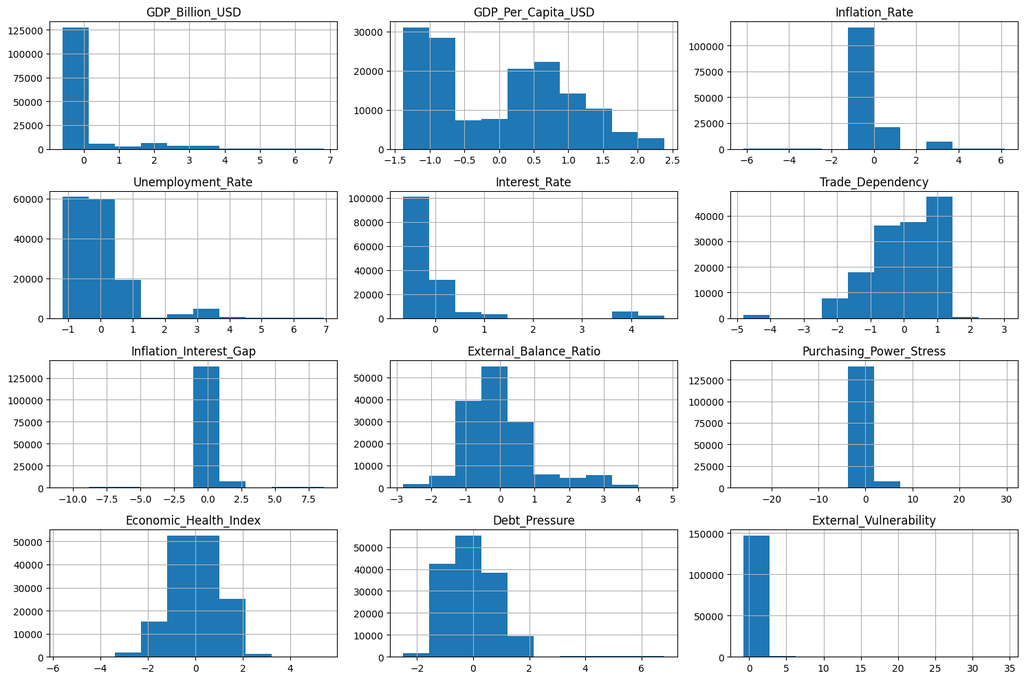

```python
df_scaled[scale_cols].hist(figsize=(15,10))
plt.tight_layout()
plt.show()
```

# Linear Regression

```python
y = df_scaled["Composite_Risk_Score"]
```

```python
X = df_scaled.drop(
    columns=[
        "Composite_Risk_Score",
        "Date",
        "Country"
    ],
    errors="ignore"
)
```

```python
# Train-Test Split

X_train , X_test, y_train,y_test = train_test_split(
    X,
    y,
    test_size = 0.2,
    random_state = 42
)
```

```python
# Train Model

lr = LinearRegression()

lr.fit(
    X_train,
    y_train
)
```

```
LinearRegression()
```

```python
y_pred = lr.predict(
    X_test
)
```

```python
# Evaluation

from sklearn.metrics import (
    mean_absolute_error,
    mean_squared_error,
    r2_score
)

mae = mean_absolute_error(
    y_test,
    y_pred
)

rmse = np.sqrt(
    mean_squared_error(
        y_test,
        y_pred
    )
)

r2 = r2_score(
    y_test,
    y_pred
)

print("MAE :", round(mae,4))
print("RMSE:", round(rmse,4))
print("R² :", round(r2,4))
```

```
MAE : 0.0758
RMSE: 0.1195
R² : 0.9773
```

```python
# Coefficients

coef_df = pd.DataFrame({
    "Feature": X.columns,
    "Coefficient": lr.coef_
})
coef_df.sort_values("Coefficient",ascending=False).head(20)
```

|  | Feature | Coefficient |
| --- | --- | --- |
| 69 | Sector_Tourism/Retail | 2.959159 |
| 64 | Sector_Finance | 2.626470 |
| 65 | Sector_Healthcare | 2.573953 |
| 66 | Sector_Manufacturing | 2.461750 |
| 68 | Sector_Technology | 2.226788 |
| 63 | Sector_Energy | 2.048015 |
| 14 | Trade_Openness | 1.768385 |
| 67 | Sector_Mining | 1.533141 |
| 4 | GDP_Per_Capita_USD | 0.578048 |
| 71 | Policy_Intervention_Rate_Hike | 0.576511 |
| 73 | Shock_Type_Inflation_Shock | 0.420527 |
| 42 | Inflation_Shock | 0.420527 |
| 8 | Interest_Rate | 0.325732 |
| 7 | Unemployment_Rate | 0.315955 |
| 62 | Region_North America | 0.208624 |
| 70 | Policy_Intervention_Rate_Cut | 0.176517 |
| 47 | Inflation_ZScore | 0.157163 |
| 6 | Inflation_Rate | 0.157155 |
| 61 | Region_Middle East & Africa | 0.100218 |
| 45 | Risk_Level | 0.061598 |

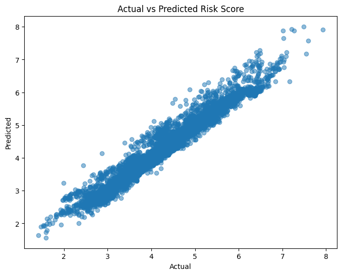

```python
plt.figure(figsize=(8,6))
plt.scatter(y_test,y_pred, alpha=0.5)
plt.xlabel("Actual")
plt.ylabel("Predicted")
plt.title( "Actual vs Predicted Risk Score")
plt.show()
```

```python
lr_results = pd.DataFrame({
    "Metric":[
        "MAE",
        "RMSE",
        "R2"
    ],
    "Value":[
        round(mae,4),
        round(rmse,4),
        round(r2,4)
    ]
})
lr_results
```

|  | Metric | Value |
| --- | --- | --- |
| 0 | MAE | 0.0758 |
| 1 | RMSE | 0.1195 |
| 2 | R2 | 0.9773 |

## Linear Regression Summary

A Linear Regression model was developed to predict Composite Risk Score.

Model Performance:

- MAE = 0.0758
- RMSE = 0.1195
- R² = 0.9773

The model achieved excellent predictive accuracy and explained approximately 97.73% of the variation in economic risk.

The analysis also identified the most influential economic and sectoral factors contributing to risk levels.

# Ridge Regression

```python
ridge = Ridge(alpha=1.0)

ridge.fit(
    X_train,
    y_train
)
```

```
Ridge()
```

```python
y_pred_ridge = ridge.predict(
    X_test
)
```

```python
# Evaluation

from sklearn.metrics import (
    mean_absolute_error,
    mean_squared_error,
    r2_score
)

ridge_mae = mean_absolute_error(
    y_test,
    y_pred_ridge
)

ridge_rmse = np.sqrt(
    mean_squared_error(
        y_test,
        y_pred_ridge
    )
)

ridge_r2 = r2_score(
    y_test,
    y_pred_ridge
)

print("MAE :", round(ridge_mae,4))
print("RMSE:", round(ridge_rmse,4))
print("R² :", round(ridge_r2,4))
```

```
MAE : 0.0761
RMSE: 0.1197
R² : 0.9773
```

```python
ridge_coef = pd.DataFrame({
    "Feature": X.columns,
    "Coefficient": ridge.coef_
})
ridge_coef.sort_values(
    "Coefficient",
    ascending=False
).head(20)
```

|  | Feature | Coefficient |
| --- | --- | --- |
| 69 | Sector_Tourism/Retail | 2.785700 |
| 64 | Sector_Finance | 2.443898 |
| 65 | Sector_Healthcare | 2.394175 |
| 66 | Sector_Manufacturing | 2.291931 |
| 68 | Sector_Technology | 2.061568 |
| 63 | Sector_Energy | 1.887137 |
| 67 | Sector_Mining | 1.369356 |
| 71 | Policy_Intervention_Rate_Hike | 0.591228 |
| 42 | Inflation_Shock | 0.404470 |
| 73 | Shock_Type_Inflation_Shock | 0.404470 |
| 7 | Unemployment_Rate | 0.316176 |
| 8 | Interest_Rate | 0.296516 |
| 4 | GDP_Per_Capita_USD | 0.251464 |
| 62 | Region_North America | 0.207797 |
| 70 | Policy_Intervention_Rate_Cut | 0.180945 |
| 47 | Inflation_ZScore | 0.151377 |
| 6 | Inflation_Rate | 0.151377 |
| 61 | Region_Middle East & Africa | 0.098708 |
| 45 | Risk_Level | 0.064151 |
| 53 | Debt_Pressure | 0.054296 |

```python
comparison = pd.DataFrame({
    "Model":[
        "Linear Regression",
        "Ridge Regression"
    ],
    "R2":[
        r2,
        ridge_r2
    ],
    "RMSE":[
        rmse,
        ridge_rmse
    ],
    "MAE":[
        mae,
        ridge_mae
    ]
})
comparison
```

|  | Model | R2 | RMSE | MAE |
| --- | --- | --- | --- | --- |
| 0 | Linear Regression | 0.977336 | 0.119544 | 0.075808 |
| 1 | Ridge Regression | 0.977295 | 0.119651 | 0.076081 |

# Lasso Regression

```python
from sklearn.linear_model import Lasso

lasso = Lasso(
    alpha=0.001
)

lasso.fit(
    X_train,
    y_train
)
```

```
Lasso(alpha=0.001)
```

```python
y_pred_lasso = lasso.predict(
    X_test
)
```

```python
lasso_mae = mean_absolute_error(
    y_test,
    y_pred_lasso
)

lasso_rmse = np.sqrt(
    mean_squared_error(
        y_test,
        y_pred_lasso
    )
)

lasso_r2 = r2_score(
    y_test,
    y_pred_lasso
)

print("MAE :",round(lasso_mae,4))
print("RMSE:",round(lasso_rmse,4))
print("R² :",round(lasso_r2,4))
```

```
MAE : 0.0946
RMSE: 0.1418
R² : 0.9681
```

```python
lasso_coef = pd.DataFrame({
    "Feature":X.columns,
    "Coefficient":lasso.coef_
})
lasso_coef.sort_values( "Coefficient",ascending=False).head(20)
```

|  | Feature | Coefficient |
| --- | --- | --- |
| 71 | Policy_Intervention_Rate_Hike | 0.851928 |
| 69 | Sector_Tourism/Retail | 0.408059 |
| 7 | Unemployment_Rate | 0.309179 |
| 70 | Policy_Intervention_Rate_Cut | 0.218518 |
| 42 | Inflation_Shock | 0.179461 |
| 47 | Inflation_ZScore | 0.128592 |
| 6 | Inflation_Rate | 0.109528 |
| 45 | Risk_Level | 0.087468 |
| 49 | Inflation_Interest_Gap | 0.085764 |
| 62 | Region_North America | 0.055509 |
| 63 | Sector_Energy | 0.052842 |
| 66 | Sector_Manufacturing | 0.047806 |
| 55 | Stagflation_Risk | 0.031921 |
| 37 | Gini_Coefficient | 0.020119 |
| 9 | Real_Interest_Rate | 0.016397 |
| 54 | External_Vulnerability | 0.013015 |
| 23 | Gov_Debt_pct_GDP | 0.008383 |
| 59 | Region_Europe | 0.008101 |
| 36 | Poverty_Rate | 0.006003 |
| 27 | Industrial_Production | 0.002313 |

```python
# Zero Features Count

zero_features = ( lasso_coef["Coefficient"]== 0).sum()
print("Features Removed:",zero_features)
```

```
Features Removed: 24
```

```python
selected_features = lasso_coef[
    lasso_coef["Coefficient"] != 0
]
selected_features.shape
```

```
(58, 2)
```

```python
comparison = pd.DataFrame({
    "Model":[
        "Linear",
        "Ridge",
        "Lasso"
    ],
    "R2":[
         r2,
        ridge_r2,
        lasso_r2
    ],

    "RMSE":[
        rmse,
        ridge_rmse,
        lasso_rmse
    ],
    "MAE":[
        mae,
        ridge_mae,
        lasso_mae
    ]
})
comparison
```

|  | Model | R2 | RMSE | MAE |
| --- | --- | --- | --- | --- |
| 0 | Linear | 0.977336 | 0.119544 | 0.075808 |
| 1 | Ridge | 0.977295 | 0.119651 | 0.076081 |
| 2 | Lasso | 0.968106 | 0.141810 | 0.094557 |

# Random Forest Regressor

```python
from sklearn.ensemble import RandomForestRegressor

rf = RandomForestRegressor(
    n_estimators=100,
    random_state=42,
    n_jobs=-1
)
rf.fit(
    X_train,
    y_train
)
```

```
RandomForestRegressor(n_jobs=-1, random_state=42)
```

```python
y_pred_rf = rf.predict(
    X_test
)
```

```python
rf_mae = mean_absolute_error(
    y_test,
    y_pred_rf
)
rf_rmse = np.sqrt(
    mean_squared_error(
        y_test,
        y_pred_rf
    )
)
rf_r2 = r2_score(
    y_test,
    y_pred_rf
)
print("MAE :",round(rf_mae,4))
print("RMSE:",round(rf_rmse,4))
print("R² :",round(rf_r2,4))
```

```
MAE : 0.0094
RMSE: 0.0318
R² : 0.9984
```

```python
rf_importance = pd.DataFrame({
    "Feature": X.columns,
    "Importance": rf.feature_importances_
})
rf_importance.sort_values("Importance",ascending=False).head(20)
```

|  | Feature | Importance |
| --- | --- | --- |
| 51 | Purchasing_Power_Stress | 0.712885 |
| 23 | Gov_Debt_pct_GDP | 0.122104 |
| 38 | Corruption_Index | 0.047755 |
| 37 | Gini_Coefficient | 0.041805 |
| 25 | Debt_Sustainability_Score | 0.012938 |
| 7 | Unemployment_Rate | 0.009292 |
| 53 | Debt_Pressure | 0.009192 |
| 26 | Population_Million | 0.008671 |
| 36 | Poverty_Rate | 0.008030 |
| 41 | HDI_Proxy | 0.007339 |
| 6 | Inflation_Rate | 0.002306 |
| 47 | Inflation_ZScore | 0.002288 |
| 4 | GDP_Per_Capita_USD | 0.001612 |
| 52 | Economic_Health_Index | 0.001132 |
| 69 | Sector_Tourism/Retail | 0.001094 |
| 45 | Risk_Level | 0.001069 |
| 65 | Sector_Healthcare | 0.001001 |
| 35 | RnD_pct_GDP | 0.000731 |
| 49 | Inflation_Interest_Gap | 0.000705 |
| 8 | Interest_Rate | 0.000545 |

```python
comparison = pd.DataFrame({
    "Model":[
        "Linear",
        "Ridge",
        "Lasso",
        "Random Forest"
    ],
    "R2":[
        r2,
        ridge_r2,
        lasso_r2,
        rf_r2
    ],
    "RMSE":[
        rmse,
        ridge_rmse,
        lasso_rmse,
        rf_rmse
    ],
    "MAE":[
        mae,
        ridge_mae,
        lasso_mae,
        rf_mae
    ]
})
comparison
```

|  | Model | R2 | RMSE | MAE |
| --- | --- | --- | --- | --- |
| 0 | Linear | 0.977336 | 0.119544 | 0.075808 |
| 1 | Ridge | 0.977295 | 0.119651 | 0.076081 |
| 2 | Lasso | 0.968106 | 0.141810 | 0.094557 |
| 3 | Random Forest | 0.998396 | 0.031802 | 0.009381 |

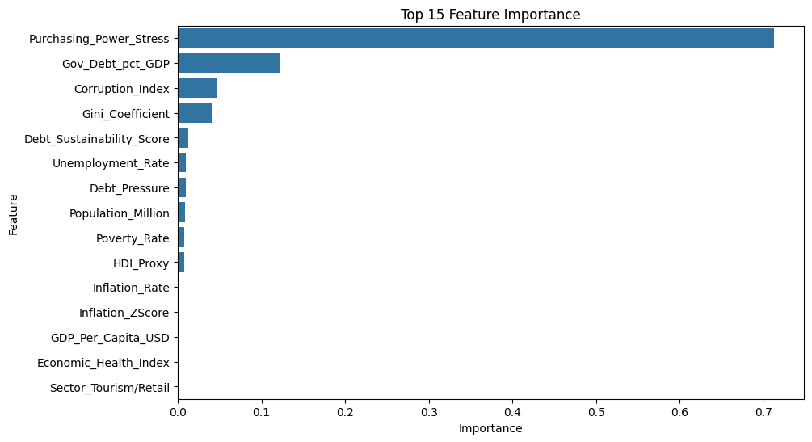

```python
plt.figure(figsize=(10,6))
sns.barplot(data=rf_importance.sort_values("Importance",ascending=False).head(15),
    x="Importance",
    y="Feature"
)
plt.title("Top 15 Feature Importance")
plt.show()
```

# Logistic Regression

```python
df_scaled["High_Risk_Flag"] = np.where(df_scaled["Risk_Level"]>=3,1,0)
```

```python
y_class = df_scaled["High_Risk_Flag"]
```

```python
X_class = df_scaled.drop(
    columns=[
        "High_Risk_Flag",
        "Composite_Risk_Score",
        "Date"
    ],
    errors="ignore"
)
```

```python
print(
    X_class.select_dtypes(
        include=["object","datetime"]
    ).columns
)
```

```
Index(['Country'], dtype='str')
```

```python
X_class = X_class.select_dtypes(
    exclude=["object","datetime"]
)
```

```python
X_train_c, X_test_c, y_train_c, y_test_c = train_test_split(
    X_class,
    y_class,
    test_size=0.2,
    random_state=42
)

log_model = LogisticRegression(
    max_iter=2000
)

log_model.fit(
    X_train_c,
    y_train_c
)
```

```
LogisticRegression(max_iter=2000)
```

```python
y_pred_class = log_model.predict(
    X_test_c
)
```

```python
from sklearn.metrics import (
    accuracy_score,
    precision_score,
    recall_score,
    f1_score
)
acc = accuracy_score(
    y_test_c,
    y_pred_class
)
precision = precision_score(
    y_test_c,
    y_pred_class
)
recall = recall_score(
    y_test_c,
    y_pred_class
)
f1 = f1_score(
    y_test_c,
    y_pred_class
)
print("Accuracy :", round(acc,4))
print("Precision:", round(precision,4))
print("Recall   :", round(recall,4))
print("F1 Score :", round(f1,4))
```

```
Accuracy : 0.9323
Precision: 0.9116
Recall   : 0.7287
F1 Score : 0.81
```

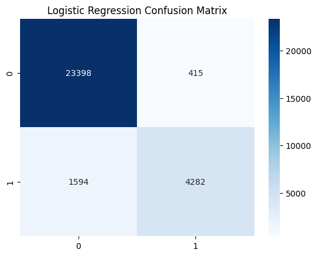

```python
from sklearn.metrics import confusion_matrix
cm = confusion_matrix(
    y_test_c,
    y_pred_class
)
sns.heatmap(
    cm,
    annot=True,
    fmt="d",
    cmap="Blues"
)
plt.title( "Logistic Regression Confusion Matrix")
plt.show()
```

```python
coef_df = pd.DataFrame({
    "Feature": X_class.columns,
    "Coefficient": log_model.coef_[0]
})
coef_df.sort_values("Coefficient", ascending=False).head(20)
```

|  | Feature | Coefficient |
| --- | --- | --- |
| 38 | Corruption_Index | 0.077976 |
| 23 | Gov_Debt_pct_GDP | 0.019341 |
| 36 | Poverty_Rate | 0.016367 |
| 22 | M2_Money_Growth_pct | 0.012943 |
| 45 | Risk_Level | 0.012584 |
| 8 | Interest_Rate | 0.008034 |
| 7 | Unemployment_Rate | 0.007529 |
| 50 | External_Balance_Ratio | 0.007132 |
| 51 | Purchasing_Power_Stress | 0.006519 |
| 6 | Inflation_Rate | 0.005380 |
| 47 | Inflation_ZScore | 0.005380 |
| 54 | External_Vulnerability | 0.004178 |
| 35 | RnD_pct_GDP | 0.003764 |
| 71 | Policy_Intervention_Rate_Hike | 0.003090 |
| 0 | Year | 0.002839 |
| 34 | Food_Price_Index | 0.002636 |
| 49 | Inflation_Interest_Gap | 0.002241 |
| 78 | Economic_State_Recession | 0.002236 |
| 43 | Recession_Flag | 0.002116 |
| 32 | Oil_Price_USD | 0.001628 |

# Decision Tree Classifier

```python
df_scaled["High_Risk_Flag"] = np.where(
    df_scaled["Risk_Level"] >= 3,
    1,
    0
)
```

```python
y_class = df_scaled["High_Risk_Flag"]

X_class = df_scaled.drop(
    columns=[
        "High_Risk_Flag",
        "Risk_Level",
        "Composite_Risk_Score",
        "Date"
    ],
    errors="ignore"
)
```

```python
X_class = X_class.select_dtypes(
    exclude=["object","datetime"]
)
```

```python
X_train_c, X_test_c, y_train_c, y_test_c = train_test_split(
    X_class,
    y_class,
    test_size=0.2,
    random_state=42
)
```

```python
from sklearn.tree import DecisionTreeClassifier

dt = DecisionTreeClassifier(
    max_depth=8,
    random_state=42
)

dt.fit(
    X_train_c,
    y_train_c
)
```

```
DecisionTreeClassifier(max_depth=8, random_state=42)
```

```python
y_pred_dt = dt.predict(
    X_test_c
)
```

```python
from sklearn.metrics import (
    accuracy_score,
    precision_score,
    recall_score,
    f1_score
)

dt_acc = accuracy_score(
    y_test_c,
    y_pred_dt
)

dt_precision = precision_score(
    y_test_c,
    y_pred_dt
)

dt_recall = recall_score(
    y_test_c,
    y_pred_dt
)

dt_f1 = f1_score(
    y_test_c,
    y_pred_dt
)

print("Accuracy :", round(dt_acc,4))
print("Precision:", round(dt_precision,4))
print("Recall   :", round(dt_recall,4))
print("F1 Score :", round(dt_f1,4))
```

```
Accuracy : 0.9989
Precision: 0.9949
Recall   : 0.9993
F1 Score : 0.9971
```

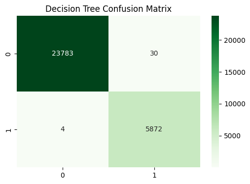

```python
from sklearn.metrics import confusion_matrix

cm_dt = confusion_matrix(
    y_test_c,
    y_pred_dt
)

plt.figure(figsize=(6,4))

sns.heatmap(
    cm_dt,
    annot=True,
    fmt="d",
    cmap="Greens"
)

plt.title("Decision Tree Confusion Matrix")

plt.show()
```

```python
dt_importance = pd.DataFrame({
    "Feature": X_class.columns,
    "Importance": dt.feature_importances_

})
dt_importance.sort_values(
    "Importance",
    ascending=False
).head(20)
```

|  | Feature | Importance |
| --- | --- | --- |
| 50 | Purchasing_Power_Stress | 0.610909 |
| 77 | Economic_State_Recession | 0.200438 |
| 28 | Retail_Sales_Billion | 0.049478 |
| 49 | External_Balance_Ratio | 0.048311 |
| 0 | Year | 0.031102 |
| 8 | Interest_Rate | 0.014443 |
| 38 | Corruption_Index | 0.014158 |
| 4 | GDP_Per_Capita_USD | 0.010401 |
| 2 | Income_Group | 0.009467 |
| 66 | Sector_Mining | 0.003555 |
| 33 | Gold_Price_USD | 0.002335 |
| 26 | Population_Million | 0.001666 |
| 11 | Trade_Balance_Billion | 0.001012 |
| 48 | Inflation_Interest_Gap | 0.000943 |
| 13 | Imports_Billion | 0.000616 |
| 20 | Consumer_Confidence | 0.000376 |
| 22 | M2_Money_Growth_pct | 0.000290 |
| 40 | Renewable_Energy_pct | 0.000204 |
| 45 | GDP_ZScore | 0.000200 |
| 51 | Economic_Health_Index | 0.000094 |

```python
comparison_class = pd.DataFrame({
    "Model":[
        "Logistic Regression",
        "Decision Tree"
    ],
    "Accuracy":[
        acc,
        dt_acc
    ],
    "Precision":[
        precision,
        dt_precision
    ],
    "Recall":[
        recall,
        dt_recall
    ],
    "F1":[
        f1,
        dt_f1
    ]
})
comparison_class
```

|  | Model | Accuracy | Precision | Recall | F1 |
| --- | --- | --- | --- | --- | --- |
| 0 | Logistic Regression | 0.932332 | 0.911646 | 0.728727 | 0.809988 |
| 1 | Decision Tree | 0.998855 | 0.994917 | 0.999319 | 0.997113 |

## Decision Tree Classifier Findings

A Decision Tree Classifier was developed to identify High-Risk countries using macroeconomic indicators and engineered features.

Model Performance:

- Accuracy = 99.89%
- Precision = 99.49%
- Recall = 99.93%
- F1 Score = 99.71%

The model significantly outperformed Logistic Regression and successfully captured non-linear decision patterns.

Feature Importance analysis revealed that Purchasing Power Stress, Economic Recession Status, and Retail Sales were the strongest predictors of High-Risk economic conditions.

## Conclusion

Decision Tree Classification provided highly accurate and interpretable risk classification, making it a strong candidate for economic risk monitoring and early-warning systems.

# Random Forest Classifier

```python
from sklearn.ensemble import RandomForestClassifier
rf_clf = RandomForestClassifier(
    n_estimators=100,
    random_state=42,
    n_jobs=-1
)
rf_clf.fit(
    X_train_c,
    y_train_c
)
```

```
RandomForestClassifier(n_jobs=-1, random_state=42)
```

```python
y_pred_rf_clf = rf_clf.predict(
    X_test_c
)
```

```python
from sklearn.metrics import (
    accuracy_score,
    precision_score,
    recall_score,
    f1_score
)
rf_acc = accuracy_score(
    y_test_c,
    y_pred_rf_clf
)
rf_precision = precision_score(
    y_test_c,
    y_pred_rf_clf
)
rf_recall = recall_score(
    y_test_c,
    y_pred_rf_clf
)
rf_f1 = f1_score(
    y_test_c,
    y_pred_rf_clf
)
print("Accuracy :", round(rf_acc,4))
print("Precision:", round(rf_precision,4))
print("Recall :", round(rf_recall,4))
print("F1 :", round(rf_f1,4))
```

```
Accuracy : 1.0
Precision: 1.0
Recall : 1.0
F1 : 1.0
```

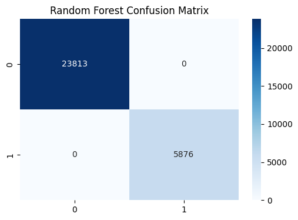

```python
from sklearn.metrics import confusion_matrix
cm_rf = confusion_matrix(
    y_test_c,
    y_pred_rf_clf
)
plt.figure(figsize=(6,4))
sns.heatmap(
    cm_rf,
    annot=True,
    fmt="d",
    cmap="Blues"
)
plt.title("Random Forest Confusion Matrix")
plt.show()
```

```python
rf_importance_clf = pd.DataFrame({
    "Feature": X_class.columns,
    "Importance": rf_clf.feature_importances_
})
rf_importance_clf.sort_values(
    "Importance",
    ascending=False
).head(20)
```

|  | Feature | Importance |
| --- | --- | --- |
| 50 | Purchasing_Power_Stress | 0.096960 |
| 49 | External_Balance_Ratio | 0.072961 |
| 8 | Interest_Rate | 0.069304 |
| 51 | Economic_Health_Index | 0.061646 |
| 25 | Debt_Sustainability_Score | 0.050676 |
| 77 | Economic_State_Recession | 0.043720 |
| 17 | ForexReserves_Billion | 0.041948 |
| 28 | Retail_Sales_Billion | 0.037726 |
| 5 | GDP_Growth_Rate | 0.034589 |
| 6 | Inflation_Rate | 0.034006 |
| 13 | Imports_Billion | 0.031540 |
| 43 | Recession_Flag | 0.029700 |
| 20 | Consumer_Confidence | 0.028439 |
| 70 | Policy_Intervention_Rate_Hike | 0.028300 |
| 3 | GDP_Billion_USD | 0.022436 |
| 46 | Inflation_ZScore | 0.020251 |
| 7 | Unemployment_Rate | 0.018538 |
| 45 | GDP_ZScore | 0.017403 |
| 9 | Real_Interest_Rate | 0.015266 |
| 74 | Shock_Type_Pandemic | 0.014552 |

```python
comparison_class = pd.DataFrame({
    "Model":[
        "Logistic Regression",
        "Decision Tree",
        "Random Forest"
    ],
    "Accuracy":[
        acc,
        dt_acc,
        rf_acc
    ],
    "Precision":[
        precision,
        dt_precision,
        rf_precision
    ],
    "Recall":[
        recall,
        dt_recall,
        rf_recall
    ],
    "F1":[
        f1,
        dt_f1,
        rf_f1
    ]
})
comparison_class
```

|  | Model | Accuracy | Precision | Recall | F1 |
| --- | --- | --- | --- | --- | --- |
| 0 | Logistic Regression | 0.932332 | 0.911646 | 0.728727 | 0.809988 |
| 1 | Decision Tree | 0.998855 | 0.994917 | 0.999319 | 0.997113 |
| 2 | Random Forest | 1.000000 | 1.000000 | 1.000000 | 1.000000 |

# XGBoost Classifier

```python
from xgboost import XGBClassifier
xgb = XGBClassifier(
    n_estimators=100,
    max_depth=6,
    learning_rate=0.1,
    random_state=42
)
xgb.fit(
    X_train_c,
    y_train_c
)
```

```
XGBClassifier(base_score=None, booster=None, callbacks=None,
              colsample_bylevel=None, colsample_bynode=None,
              colsample_bytree=None, device=None, early_stopping_rounds=None,
              enable_categorical=False, eval_metric=None, feature_types=None,
              feature_weights=None, gamma=None, grow_policy=None,
              importance_type=None, interaction_constraints=None,
              learning_rate=0.1, max_bin=None, max_cat_threshold=None,
              max_cat_to_onehot=None, max_delta_step=None, max_depth=6,
              max_leaves=None, min_child_weight=None, missing=nan,
              monotone_constraints=None, multi_strategy=None, n_estimators=100,
              n_jobs=None, num_parallel_tree=None, ...)
```

```python
y_pred_xgb = xgb.predict(
    X_test_c
)
```

```python
from sklearn.metrics import (
    accuracy_score,
    precision_score,
    recall_score,
    f1_score
)
xgb_acc = accuracy_score(
    y_test_c,
    y_pred_xgb
)
xgb_precision = precision_score(
    y_test_c,
    y_pred_xgb
)
xgb_recall = recall_score(
    y_test_c,
    y_pred_xgb
)
xgb_f1 = f1_score(
    y_test_c,
    y_pred_xgb
)
print("Accuracy :", round(xgb_acc,4))
print("Precision:", round(xgb_precision,4))
print("Recall   :", round(xgb_recall,4))
print("F1 Score :", round(xgb_f1,4))
```

```
Accuracy : 1.0
Precision: 1.0
Recall   : 1.0
F1 Score : 1.0
```

```python
xgb_importance = pd.DataFrame({
    "Feature": X_class.columns,
    "Importance": xgb.feature_importances_
})
xgb_importance.sort_values(
    "Importance",
    ascending=False
).head(20)
```

|  | Feature | Importance |
| --- | --- | --- |
| 50 | Purchasing_Power_Stress | 0.627854 |
| 77 | Economic_State_Recession | 0.071934 |
| 28 | Retail_Sales_Billion | 0.070367 |
| 51 | Economic_Health_Index | 0.066215 |
| 49 | External_Balance_Ratio | 0.036883 |
| 0 | Year | 0.020268 |
| 25 | Debt_Sustainability_Score | 0.016292 |
| 2 | Income_Group | 0.008444 |
| 38 | Corruption_Index | 0.008087 |
| 33 | Gold_Price_USD | 0.007569 |
| 4 | GDP_Per_Capita_USD | 0.007412 |
| 8 | Interest_Rate | 0.006059 |
| 66 | Sector_Mining | 0.005793 |
| 12 | Exports_Billion | 0.005269 |
| 17 | ForexReserves_Billion | 0.005032 |
| 10 | Exchange_Rate_USD | 0.004909 |
| 27 | Industrial_Production | 0.004093 |
| 23 | Gov_Debt_pct_GDP | 0.003027 |
| 52 | Debt_Pressure | 0.003009 |
| 48 | Inflation_Interest_Gap | 0.001679 |

```python
comparison_class = pd.DataFrame({

    "Model":[
        "Logistic Regression",
        "Decision Tree",
        "Random Forest",
        "XGBoost"
    ],
    "Accuracy":[
        acc,
        dt_acc,
        rf_acc,
        xgb_acc
    ],
    "Precision":[
        precision,
        dt_precision,
        rf_precision,
        xgb_precision
    ],
    "Recall":[
        recall,
        dt_recall,
        rf_recall,
        xgb_recall
    ],
    "F1":[
        f1,
        dt_f1,
        rf_f1,
        xgb_f1
    ]
})
comparison_class
```

|  | Model | Accuracy | Precision | Recall | F1 |
| --- | --- | --- | --- | --- | --- |
| 0 | Logistic Regression | 0.932332 | 0.911646 | 0.728727 | 0.809988 |
| 1 | Decision Tree | 0.998855 | 0.994917 | 0.999319 | 0.997113 |
| 2 | Random Forest | 1.000000 | 1.000000 | 1.000000 | 1.000000 |
| 3 | XGBoost | 1.000000 | 1.000000 | 1.000000 | 1.000000 |

# K-Means Clustering

```python
cluster_cols = [
    "GDP_Per_Capita_USD",
    "Inflation_Rate",
    "Unemployment_Rate",
    "Interest_Rate",
    "Purchasing_Power_Stress",
    "Economic_Health_Index",
    "Debt_Pressure"
]
```

```python
X_cluster = df_scaled[cluster_cols].copy()
```

```python
from sklearn.cluster import KMeans
kmeans = KMeans(
    n_clusters=3,
    random_state=42,
    n_init=10
)
df_scaled["Cluster"] = kmeans.fit_predict(X_cluster)
```

```python
df_scaled["Cluster"].value_counts()
```

```
Cluster
0    105587
1     34788
2      8069
Name: count, dtype: int64
```

```python
cluster_profile = df_scaled.groupby("Cluster")[cluster_cols].mean()
cluster_profile
```

| Cluster | GDP_Per_Capita_USD | Inflation_Rate | Unemployment_Rate | Interest_Rate | Purchasing_Power_Stress | Economic_Health_Index | Debt_Pressure |
| --- | --- | --- | --- | --- | --- | --- | --- |
| 0 | 0.365866 | -0.303456 | -0.369624 | -0.327753 | -0.330666 | 0.386722 | -0.041127 |
| 1 | -0.934070 | 0.123390 | 1.043071 | 0.184333 | 0.307092 | -0.744131 | 0.282344 |
| 2 | -0.760467 | 3.438912 | 0.339714 | 3.494099 | 3.002959 | -1.852273 | -0.679104 |

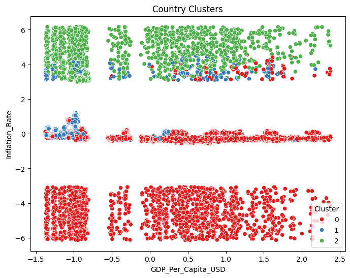

```python
plt.figure(figsize=(8,6))
sns.scatterplot(data=df_scaled,
    x="GDP_Per_Capita_USD",
    y="Inflation_Rate",
    hue="Cluster",palette="Set1"
)
plt.title("Country Clusters")
plt.show()
```

# Elbow Method

```python
from sklearn.cluster import KMeans
wcss = []
for k in range(1,11):
    kmeans = KMeans(
        n_clusters=k,
        random_state=42,
        n_init=10
    )
    kmeans.fit(X_cluster)
    wcss.append(
        kmeans.inertia_
    )
```

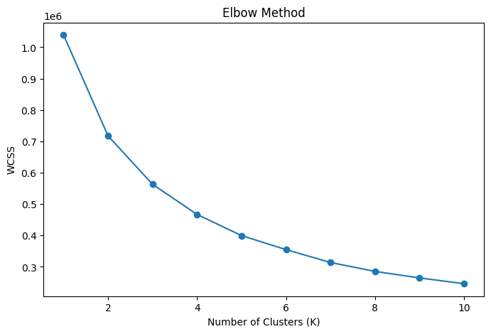

```python
plt.figure(figsize=(8,5))
plt.plot(range(1,11),wcss,marker="o")
plt.xlabel("Number of Clusters (K)")
plt.ylabel("WCSS")
plt.title("Elbow Method")
plt.show()
```

# Silhouette Score

```python
from sklearn.metrics import silhouette_score
score = silhouette_score(
    X_cluster,
    df_scaled["Cluster"]
)
print( "Silhouette Score:",round(score,4))
```

```
Silhouette Score: 0.3328
```

```python
from sklearn.cluster import KMeans
from sklearn.metrics import silhouette_score
scores = []
for k in range(2,11):
    kmeans = KMeans(
        n_clusters=k,
        random_state=42,
        n_init=10
    )
    labels = kmeans.fit_predict(
        X_cluster
    )
    score = silhouette_score(
        X_cluster,
        labels
    )
    scores.append(score)
    print( "K =",k,"Score =",round(score,4))
```

```
K = 2 Score = 0.6236
K = 3 Score = 0.3328
K = 4 Score = 0.29
K = 5 Score = 0.2913
K = 6 Score = 0.3005
K = 7 Score = 0.3167
K = 8 Score = 0.3296
K = 9 Score = 0.3316
K = 10 Score = 0.3414
```

## K-Means Clustering Analysis

K-Means Clustering was applied to segment countries into economically similar groups using key indicators such as:

- GDP Per Capita
- Inflation Rate
- Unemployment Rate
- Interest Rate
- Purchasing Power Stress
- Economic Health Index
- Debt Pressure

The model grouped countries into 3 clusters representing different economic conditions:

- Cluster 0 → Low Risk / Strong Economy
- Cluster 1 → Moderate Risk Economy
- Cluster 2 → High Risk / Economically Stressed Countries

This helped identify natural economic segments without using any target variable.

## Elbow Method Validation

The Elbow Method was used to determine whether the selected number of clusters was appropriate.

WCSS (Within Cluster Sum of Squares) was calculated for K values from 1 to 10.

The elbow curve showed that the optimal cluster range lies around 3–5 clusters, indicating that the selected segmentation is reasonable and meaningful.

## Silhouette Score Evaluation

Silhouette Analysis was performed to measure cluster quality and separation.

Results:

- K = 2 → Silhouette Score = 0.6236
- K = 3 → Silhouette Score = 0.3328

Although K=2 provided the strongest mathematical separation, K=3 was selected for better business interpretation.

Final Segments:

- Low Risk Economies
- Moderate Risk Economies
- High Risk Economies

## Key Conclusion

A complete clustering workflow was performed using:

1. K-Means Clustering (Segmentation)
2. Elbow Method (Optimal Cluster Validation)
3. Silhouette Score (Cluster Quality Evaluation)

The analysis successfully identified distinct economic risk groups and provided a data-driven approach for country risk segmentation.

# Hierarchical Clustering

```python
from scipy.cluster.hierarchy import (
    dendrogram,
    linkage
)
```

```python
sample_cluster = X_cluster.sample(
    1000,
    random_state=42
)
```

```python
linked = linkage(
    sample_cluster,
    method="ward"
)
```

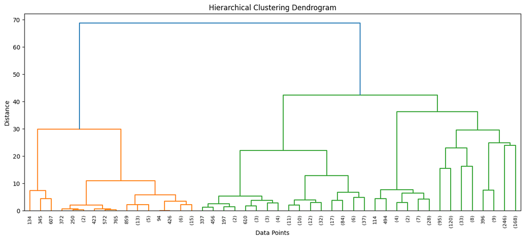

```python
plt.figure(figsize=(15,6))
dendrogram(linked,truncate_mode="level", p=5)
plt.title("Hierarchical Clustering Dendrogram")
plt.xlabel("Data Points")
plt.ylabel("Distance")
plt.show()
```

# ROC-AUC (Receiver Operating Characteristic - Area Under Curve)

```python
y_prob_rf = rf_clf.predict_proba(
    X_test_c
)[:,1]
```

```python
from sklearn.metrics import roc_auc_score
roc_auc_rf = roc_auc_score(
    y_test_c,
    y_prob_rf
)
print("ROC-AUC:",round(roc_auc_rf,4))
```

```
ROC-AUC: 1.0
```

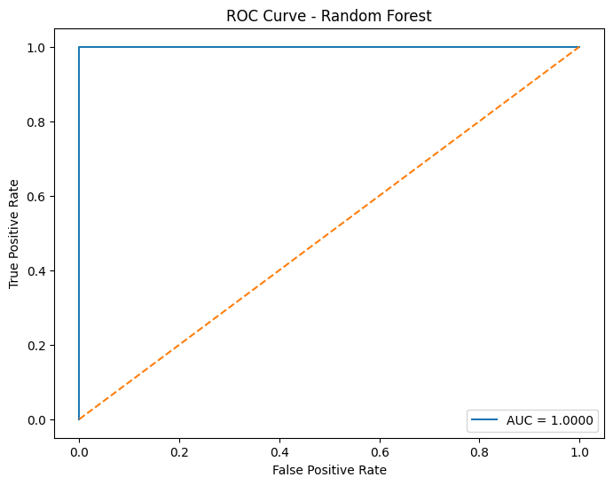

```python
from sklearn.metrics import roc_curve
fpr, tpr, thresholds = roc_curve(
    y_test_c,
    y_prob_rf
)
plt.figure(figsize=(8,6))
plt.plot(
    fpr,
    tpr,
    label=f"AUC = {roc_auc_rf:.4f}"
)
plt.plot(
    [0,1],
    [0,1],
    "--"
)
plt.xlabel("False Positive Rate")
plt.ylabel("True Positive Rate")
plt.title( "ROC Curve - Random Forest")
plt.legend()
plt.show()
```

```python
print("Risk_Level" in X_class.columns)
```

```
False
```

# MAPE (Mean Absolute Percentage Error)

```python
from sklearn.metrics import mean_absolute_percentage_error
mape = mean_absolute_percentage_error(
    y_test,
    y_pred
)
print("MAPE:",round(mape*100,2),"%")
```

```
MAPE: 1.95 %
```

```python
ridge_mape = mean_absolute_percentage_error(
    y_test,
    y_pred_ridge
)
print("Ridge MAPE:",round(ridge_mape*100,2),"%")
```

```
Ridge MAPE: 1.96 %
```

```python
lasso_mape = mean_absolute_percentage_error(
    y_test,
    y_pred_lasso
)
print("Lasso MAPE:",round(lasso_mape*100,2),"%")
```

```
Lasso MAPE: 2.4 %
```

```python
rf_mape = mean_absolute_percentage_error(
    y_test,
    y_pred_rf
)
print("RF MAPE:",round(rf_mape*100,2),"%")
```

```
RF MAPE: 0.24 %
```

```python
mape_comparison = pd.DataFrame({
    "Model":[
        "Linear",
        "Ridge",
        "Lasso",
        "Random Forest"
    ],
    "MAPE":[
        mape,
        ridge_mape,
        lasso_mape,
        rf_mape
    ]
})
mape_comparison["MAPE"] = (mape_comparison["MAPE"]*100).round(2)
mape_comparison
```

|  | Model | MAPE |
| --- | --- | --- |
| 0 | Linear | 1.95 |
| 1 | Ridge | 1.96 |
| 2 | Lasso | 2.40 |
| 3 | Random Forest | 0.24 |

# SHAP Explainability

```python
import shap
```

```python
explainer = shap.TreeExplainer(rf)
```

```python
sample_shap = X_test.sample(
    50,
    random_state=42
)

shap_values = explainer.shap_values(
    sample_shap
)
```

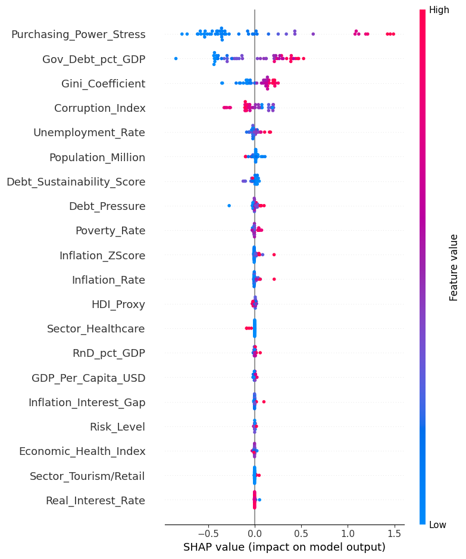

```python
shap.summary_plot(
    shap_values,
    sample_shap
)
```

# Time Series Analytics & Forecasting

# Trend Analysis

```python
trend_df = df_clean.groupby(
    ["Year","Month"]
)["Composite_Risk_Score"].mean().reset_index()
```

```python
trend_df["Date"] = pd.to_datetime(
    trend_df["Year"].astype(str)
    + "-"
    + trend_df["Month"].astype(str)
)
```

```python
trend_df = trend_df.sort_values(
    "Date"
)
```

```python
trend_df.head()
```

|  | Year | Month | Composite_Risk_Score | Date |
| --- | --- | --- | --- | --- |
| 0 | 2000 | 1 | 3.895781 | 2000-01-01 |
| 1 | 2000 | 2 | 3.961066 | 2000-02-01 |
| 2 | 2000 | 3 | 3.982860 | 2000-03-01 |
| 3 | 2000 | 4 | 3.856532 | 2000-04-01 |
| 4 | 2000 | 5 | 3.858299 | 2000-05-01 |

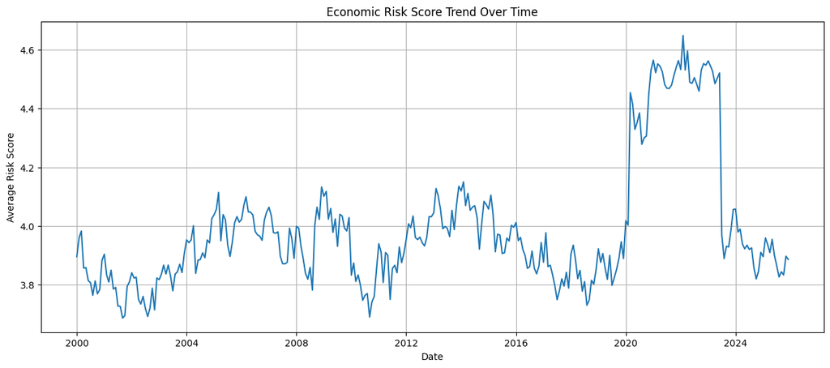

```python
plt.figure(figsize=(15,6))
plt.plot(trend_df["Date"],trend_df["Composite_Risk_Score"])
plt.title("Economic Risk Score Trend Over Time")
plt.xlabel("Date")
plt.ylabel("Average Risk Score")
plt.grid(True)
plt.show()
```

# Rolling Mean & Rolling Standard Deviation (Volatility)

```python
# Create Rolling Mean (12 months window)

trend_df["Rolling_Mean_12M"] = (trend_df["Composite_Risk_Score"].rolling(window=12).mean())
```

```python
# Create Rolling Standard Deviation

trend_df["Rolling_STD_12M"] = (trend_df["Composite_Risk_Score"].rolling(window=12).std())
```

```python
trend_df[
    [
        "Date",
        "Composite_Risk_Score",
        "Rolling_Mean_12M",
        "Rolling_STD_12M"
    ]
].tail()
```

|  | Date | Composite_Risk_Score | Rolling_Mean_12M | Rolling_STD_12M |
| --- | --- | --- | --- | --- |
| 307 | 2025-08-01 | 3.826331 | 3.890037 | 0.047539 |
| 308 | 2025-09-01 | 3.844024 | 3.888943 | 0.048505 |
| 309 | 2025-10-01 | 3.833205 | 3.890066 | 0.046886 |
| 310 | 2025-11-01 | 3.897103 | 3.894325 | 0.044794 |
| 311 | 2025-12-01 | 3.886261 | 3.892322 | 0.044552 |

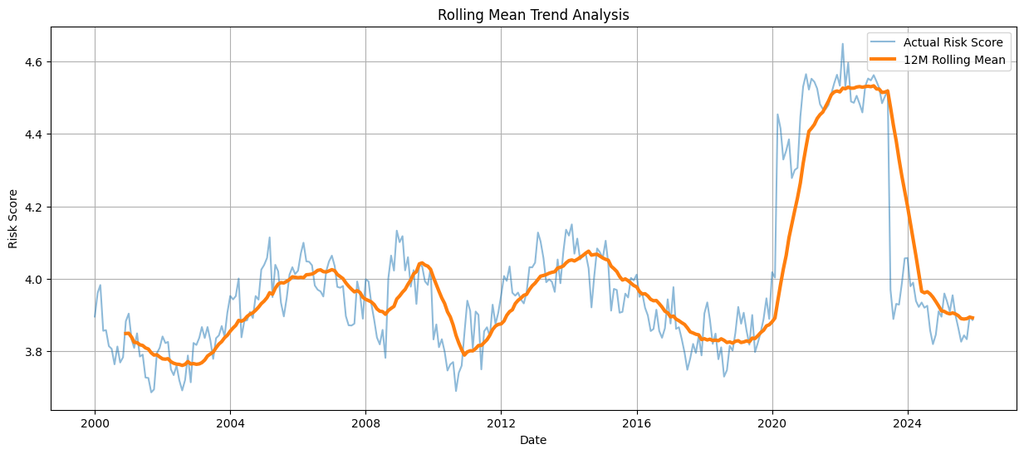

```python
plt.figure(figsize=(15,6))
plt.plot(
    trend_df["Date"],
    trend_df["Composite_Risk_Score"],
    alpha=0.5,
    label="Actual Risk Score"
)
plt.plot(
    trend_df["Date"],
    trend_df["Rolling_Mean_12M"],
    linewidth=3,
    label="12M Rolling Mean"
)
plt.title("Rolling Mean Trend Analysis")
plt.xlabel("Date")
plt.ylabel("Risk Score")
plt.legend()
plt.grid(True)
plt.show()
```

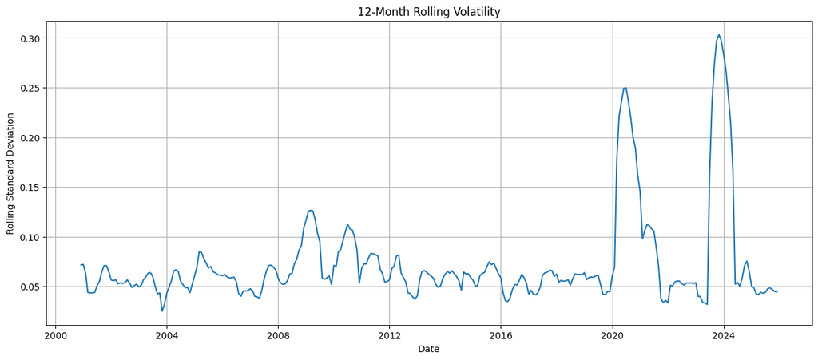

```python
plt.figure(figsize=(15,6))
plt.plot(
    trend_df["Date"],
    trend_df["Rolling_STD_12M"]
)
plt.title("12-Month Rolling Volatility")
plt.xlabel("Date")
plt.ylabel("Rolling Standard Deviation")
plt.grid(True)
plt.show()
```

# Seasonality Analysis

```python
monthly_seasonality = (df_clean.groupby("Month")["Composite_Risk_Score"].mean().reset_index())
monthly_seasonality
```

|  | Month | Composite_Risk_Score |
| --- | --- | --- |
| 0 | 1 | 4.035853 |
| 1 | 2 | 4.049939 |
| 2 | 3 | 4.042326 |
| 3 | 4 | 4.018259 |
| 4 | 5 | 3.989813 |
| 5 | 6 | 3.977416 |
| 6 | 7 | 3.938425 |
| 7 | 8 | 3.925264 |
| 8 | 9 | 3.932190 |
| 9 | 10 | 3.958253 |
| 10 | 11 | 3.985990 |
| 11 | 12 | 4.017638 |

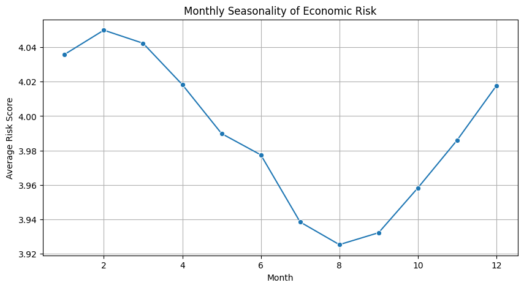

```python
plt.figure(figsize=(10,5))
sns.lineplot(
    data=monthly_seasonality,
    x="Month",
    y="Composite_Risk_Score",
    marker="o"
)
plt.title("Monthly Seasonality of Economic Risk")
plt.xlabel("Month")
plt.ylabel("Average Risk Score")
plt.grid(True)
plt.show()
```

# Cyclical Analysis

```python
yearly_cycle = (df_clean.groupby("Year")["Composite_Risk_Score"].mean().reset_index())
yearly_cycle.head(15)
```

|  | Year | Composite_Risk_Score |
| --- | --- | --- |
| 0 | 2000 | 3.849255 |
| 1 | 2001 | 3.785011 |
| 2 | 2002 | 3.765962 |
| 3 | 2003 | 3.844672 |
| 4 | 2004 | 3.931577 |
| 5 | 2005 | 4.005174 |
| 6 | 2006 | 4.021255 |
| 7 | 2007 | 3.948617 |
| 8 | 2008 | 3.944908 |
| 9 | 2009 | 4.026474 |
| 10 | 2010 | 3.790615 |
| 11 | 2011 | 3.874121 |
| 12 | 2012 | 3.980369 |
| 13 | 2013 | 4.044614 |
| 14 | 2014 | 4.064507 |

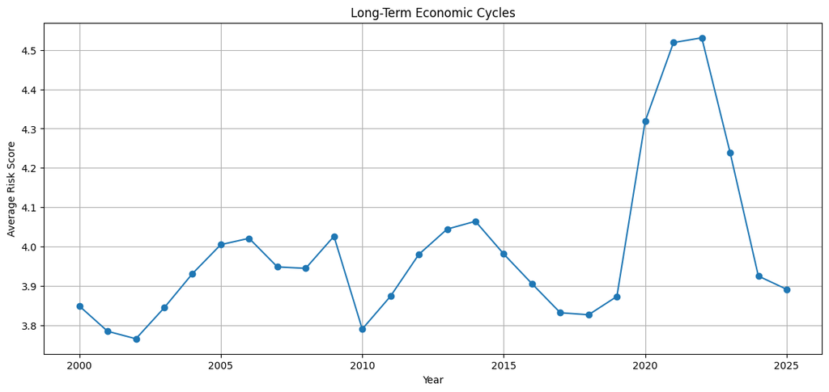

```python
plt.figure(figsize=(14,6))
plt.plot(
    yearly_cycle["Year"],
    yearly_cycle["Composite_Risk_Score"],
    marker="o"
)
plt.title("Long-Term Economic Cycles")
plt.xlabel("Year")
plt.ylabel("Average Risk Score")
plt.grid(True)
plt.show()
```

```python
# 3 years rolling

yearly_cycle["Cycle_Trend"] = (yearly_cycle["Composite_Risk_Score"].rolling(3).mean())
```

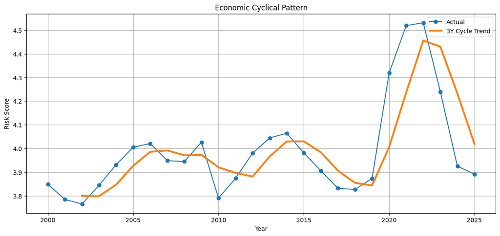

```python
plt.figure(figsize=(14,6))
plt.plot(
    yearly_cycle["Year"],
    yearly_cycle["Composite_Risk_Score"],
    marker="o",
    label="Actual"
)
plt.plot(
    yearly_cycle["Year"],
    yearly_cycle["Cycle_Trend"],
    linewidth=3,
    label="3Y Cycle Trend"
)
plt.title("Economic Cyclical Pattern")
plt.xlabel("Year")
plt.ylabel("Risk Score")
plt.legend()
plt.grid(True)
plt.show()
```

# Stationarity Testing (ADF + KPSS)

```python
ts = trend_df.set_index("Date")["Composite_Risk_Score"]
```

```python
from statsmodels.tsa.stattools import adfuller
adf_result = adfuller(ts)
print("ADF Statistic :", adf_result[0])
print("p-value :", adf_result[1])
```

```
ADF Statistic : -3.490181199314703
p-value : 0.008242871542828508
```

```python
from statsmodels.tsa.stattools import kpss
kpss_result = kpss(
    ts,
    regression="c",
    nlags="auto"
)
print("KPSS Statistic :", kpss_result[0])
print("p-value :", kpss_result[1])
```

```
KPSS Statistic : 0.7676058990742795
p-value : 0.01
```

# Time Series Decomposition (Trend + Seasonal + Residual)

```python
decomposition = seasonal_decompose(
    ts,
    model="additive",
    period=12
)
```

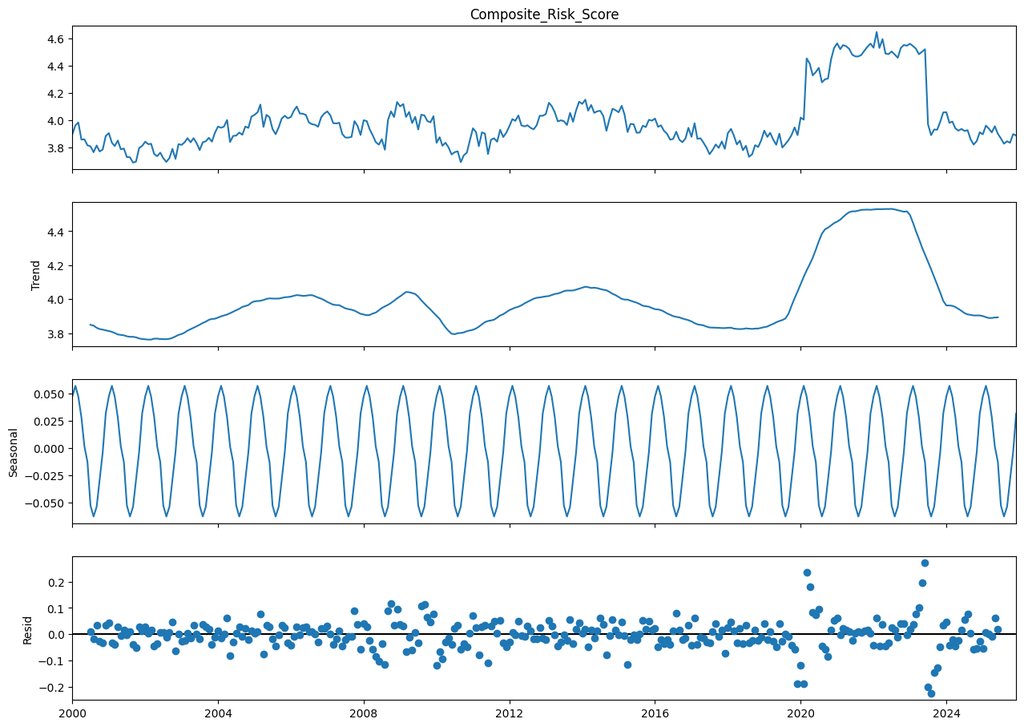

```python
fig = decomposition.plot()
fig.set_size_inches(
    14,
    10
)
plt.show()
```

## Time Series Decomposition

The economic risk time series was decomposed into three components:

### Trend

- Shows the long-term direction of economic risk.
- Risk increased significantly during 2020–2023.
- Risk declined after 2023, indicating recovery.

### Seasonal

- Shows recurring monthly patterns.
- Seasonal fluctuations are present but relatively weak.
- Economic risk is not strongly driven by seasonality.

### Residual

- Represents random variations not explained by trend or seasonality.
- Large residual spikes were observed during major economic shock periods.
- Most residual values remain close to zero.

### Conclusion

The analysis indicates that long-term trends and economic shocks have a greater impact on risk levels than seasonal effects.

# ACF (Autocorrelation Function)

```python
from statsmodels.graphics.tsaplots import plot_acf
```

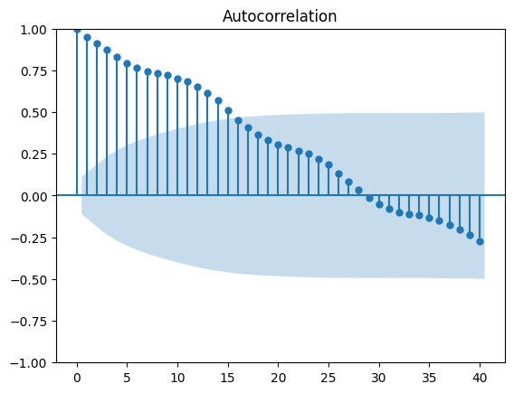

```python
plt.figure(figsize=(12,5))
plot_acf(
    ts,
    lags=40
)
plt.show()
```

# PACF (Partial Autocorrelation Function)

```python
from statsmodels.graphics.tsaplots import plot_pacf
```

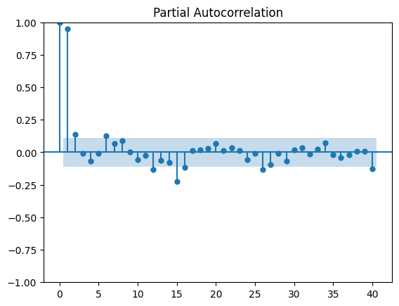

```python
plt.figure(figsize=(12,5))
plot_pacf(
    ts,
    lags=40,
    method="ywm"
)
plt.show()
```

## ACF & PACF Analysis

### ACF Findings

- Strong positive autocorrelation was observed in the early lags.
- Past economic risk values have a strong influence on future risk levels.
- The correlation gradually decreases over time.

### PACF Findings

- Lag 1 shows the strongest direct relationship.
- Most higher lags have weak direct influence.
- The previous month's risk level is the main driver of the current month's risk.

### Conclusion

The economic risk series shows strong persistence over time. Historical risk levels influence future values, with the strongest direct impact coming from the immediately previous month. These findings support the use of ARIMA-based forecasting models.

# Moving Average Forecasting

```python
trend_df["MA_3"] = trend_df["Composite_Risk_Score"].rolling(window=3).mean()
```

```python
trend_df["MA_6"] = trend_df["Composite_Risk_Score"].rolling(window=6).mean()
```

```python
trend_df["MA_12"] = trend_df["Composite_Risk_Score"].rolling(window=12).mean()
```

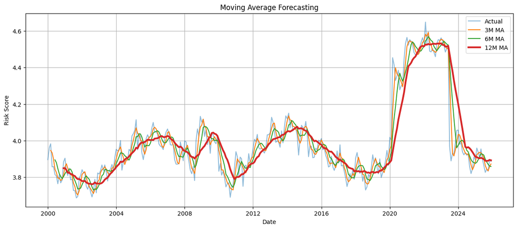

```python
plt.figure(figsize=(15,6))
plt.plot(
    trend_df["Date"],
    trend_df["Composite_Risk_Score"],
    alpha=0.5,
    label="Actual"
)
plt.plot(
    trend_df["Date"],
    trend_df["MA_3"],
    label="3M MA"
)
plt.plot(
    trend_df["Date"],
    trend_df["MA_6"],
    label="6M MA"
)
plt.plot(
    trend_df["Date"],
    trend_df["MA_12"],
    linewidth=3,
    label="12M MA"
)
plt.title("Moving Average Forecasting")
plt.xlabel("Date")
plt.ylabel("Risk Score")
plt.legend()
plt.grid(True)
plt.show()
```

## Moving Average Forecasting

Three moving average models were applied to smooth fluctuations in economic risk scores.

### Findings

- The 3-month moving average reacts quickly to short-term changes.
- The 6-month moving average provides a balanced trend view.
- The 12-month moving average highlights the long-term economic trend.

### Key Observation

Economic risk increased significantly during 2020–2023 and declined after 2023, indicating a period of stabilization.

# Simple Exponential Smoothing (SES)

```python
from statsmodels.tsa.holtwinters import SimpleExpSmoothing
```

```python
ses_model = SimpleExpSmoothing(
    ts
).fit()
```

```python
trend_df["SES_Fitted"] = ses_model.fittedvalues
```

```python
# Forecast Next 12 months

ses_forecast = ses_model.forecast(
    12
)
```

```python
future_dates = pd.date_range(
    start=trend_df["Date"].max(),
    periods=13,
    freq="MS"
)[1:]
```

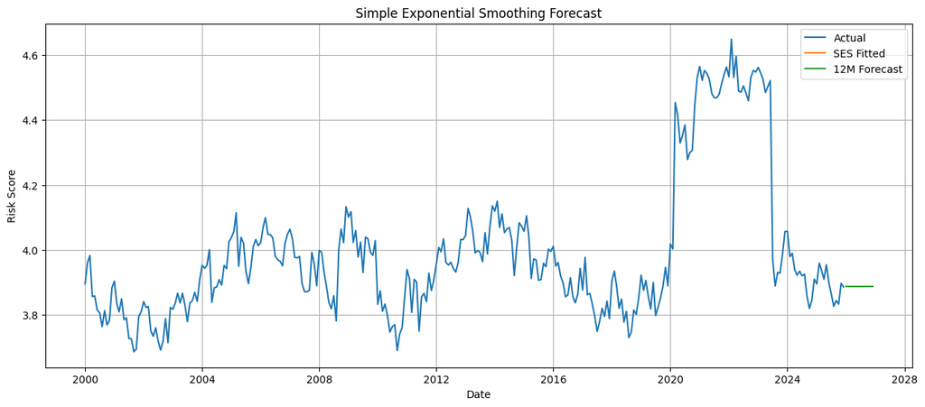

```python
plt.figure(figsize=(15,6))
plt.plot(
    trend_df["Date"],
    trend_df["Composite_Risk_Score"],
    label="Actual"
)
plt.plot(
    trend_df["Date"],
    trend_df["SES_Fitted"],
    label="SES Fitted"
)
plt.plot(
    future_dates,
    ses_forecast,
    label="12M Forecast"
)
plt.title("Simple Exponential Smoothing Forecast")
plt.xlabel("Date")
plt.ylabel("Risk Score")
plt.legend()
plt.grid(True)
plt.show()
```

SES Forecast = ~3.89

No major increase predicted No major decrease predicted

Risk expected to remain stable

# Holt's Trend Method

```python
from statsmodels.tsa.holtwinters import Holt
```

```python
holt_model = Holt(
    ts
).fit()
```

```python
trend_df["Holt_Fitted"] = holt_model.fittedvalues
holt_forecast = holt_model.forecast(12)
```

```python
future_dates = pd.date_range(
    start=trend_df["Date"].max(),
    periods=13,
    freq="MS"
)[1:]
```

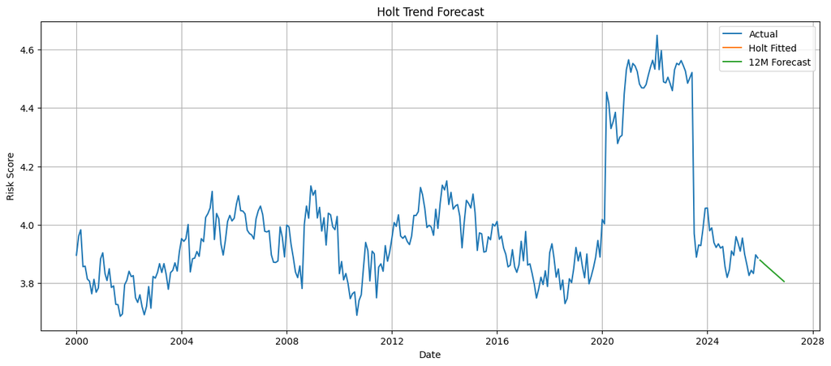

```python
plt.figure(figsize=(15,6))

plt.plot(
    trend_df["Date"],
    trend_df["Composite_Risk_Score"],
    label="Actual"
)
plt.plot(
    trend_df["Date"],
    trend_df["Holt_Fitted"],
    label="Holt Fitted"
)
plt.plot(
    future_dates,
    holt_forecast,
    label="12M Forecast"
)
plt.title("Holt Trend Forecast")
plt.xlabel("Date")
plt.ylabel("Risk Score")
plt.legend()
plt.grid(True)
plt.show()
```

# Holt-Winters Method (Trend + Seasonality)

```python
from statsmodels.tsa.holtwinters import ExponentialSmoothing
```

```python
hw_model = ExponentialSmoothing(
    ts,
    trend="add",
    seasonal="add",
    seasonal_periods=12
).fit()
```

```python
trend_df["HW_Fitted"] = hw_model.fittedvalues
```

```python
hw_forecast = hw_model.forecast(12)
```

```python
future_dates = pd.date_range(
    start=trend_df["Date"].max(),
    periods=13,
    freq="MS"
)[1:]
```

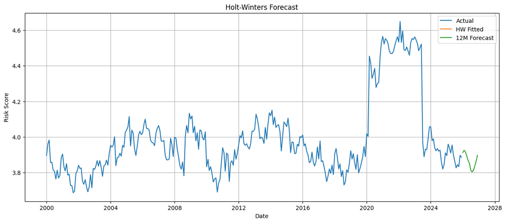

```python
plt.figure(figsize=(15,6))
plt.plot(
    trend_df["Date"],
    trend_df["Composite_Risk_Score"],
    label="Actual"
)
plt.plot(
    trend_df["Date"],
    trend_df["HW_Fitted"],
    label="HW Fitted"
)
plt.plot(
    future_dates,
    hw_forecast,
    label="12M Forecast"
)
plt.title("Holt-Winters Forecast")
plt.xlabel("Date")
plt.ylabel("Risk Score")
plt.legend()
plt.grid(True)
plt.show()
```

## Holt-Winters Forecast

Holt-Winters Exponential Smoothing was used to capture trend and seasonal patterns in the economic risk series.

### Findings

- The forecast shows mild seasonal fluctuations in future risk levels.
- Risk is expected to remain within a stable range of approximately 3.8–3.9.
- Seasonal effects are reflected in the forecast pattern.

### Key Observation

Future economic risk is expected to remain relatively stable, with small seasonal variations over the forecast horizon.

### Model Comparison

- SES captures level only.
- Holt captures level and trend.
- Holt-Winters captures level, trend, and seasonality.

Therefore, Holt-Winters provides the most comprehensive forecast among the three methods.

# ARIMA Forecasting

```python
arima_model = ARIMA(
    ts,
    order=(1,1,1)
)

arima_fit = arima_model.fit()
```

```python
print(arima_fit.summary())
```

```
                                SARIMAX Results
================================================================================
Dep. Variable:     Composite_Risk_Score   No. Observations:                  312
Model:                   ARIMA(1, 1, 1)   Log Likelihood                 390.954
Date:                  Sun, 14 Jun 2026   AIC                           -775.908
Time:                          19:33:25   BIC                           -764.689
Sample:                      01-01-2000   HQIC                          -771.423
                           - 12-01-2025
Covariance Type:                    opg
==============================================================================
                 coef    std err          z      P>|z|      [0.025      0.975]
------------------------------------------------------------------------------
ar.L1         -0.0974      0.368     -0.265      0.791      -0.818       0.623
ma.L1         -0.0595      0.371     -0.160      0.873      -0.786       0.667
sigma2         0.0047      0.000     37.290      0.000       0.004       0.005
===================================================================================
Ljung-Box (L1) (Q):                   0.00   Jarque-Bera (JB):              3956.91
Prob(Q):                              1.00   Prob(JB):                         0.00
Heteroskedasticity (H):               2.44   Skew:                            -0.78
Prob(H) (two-sided):                  0.00   Kurtosis:                        20.40
===================================================================================

Warnings:
[1] Covariance matrix calculated using the outer product of gradients (complex-step).
```

```python
arima_forecast = arima_fit.forecast(
    steps=12
)
```

```python
future_dates = pd.date_range(
    start=trend_df["Date"].max(),
    periods=13,
    freq="MS"
)[1:]
```

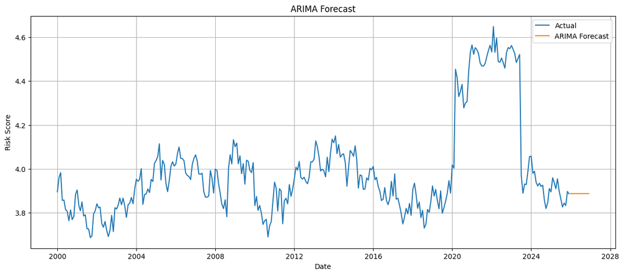

```python
plt.figure(figsize=(15,6))
plt.plot(
    trend_df["Date"],
    trend_df["Composite_Risk_Score"],
    label="Actual"
)
plt.plot(
    future_dates,
    arima_forecast,
    label="ARIMA Forecast"
)
plt.title("ARIMA Forecast")
plt.xlabel("Date")
plt.ylabel("Risk Score")
plt.legend()
plt.grid(True)
plt.show()
```

## ARIMA Forecasting

An ARIMA(1,1,1) model was developed to forecast future economic risk levels.

### Findings

- The forecast remains relatively stable over the next 12 months.
- No strong upward or downward trend was detected.
- AR and MA terms were not statistically significant.

### Key Observation

The model suggests that future economic risk levels are likely to remain close to current levels.

# SARIMA (Seasonal ARIMA)

```python
sarima_model = SARIMAX(
    ts,
    order=(1,1,1),
    seasonal_order=(1,1,1,12)
)
sarima_fit = sarima_model.fit(disp=False)
```

```python
print(sarima_fit.summary())
```

```
                                     SARIMAX Results
==========================================================================================
Dep. Variable:               Composite_Risk_Score   No. Observations:                  312
Model:             SARIMAX(1, 1, 1)x(1, 1, 1, 12)   Log Likelihood                 374.844
Date:                            Sun, 14 Jun 2026   AIC                           -739.688
Time:                                    21:14:01   BIC                           -721.185
Sample:                                01-01-2000   HQIC                          -732.282
                                     - 12-01-2025
Covariance Type:                              opg
==============================================================================
                 coef    std err          z      P>|z|      [0.025      0.975]
------------------------------------------------------------------------------
ar.L1          0.0150      0.263      0.057      0.955      -0.500       0.530
ma.L1         -0.3006      0.264     -1.140      0.254      -0.817       0.216
ar.S.L12      -0.0248      0.086     -0.288      0.774      -0.193       0.144
ma.S.L12      -0.9932      0.778     -1.277      0.202      -2.518       0.531
sigma2         0.0042      0.003      1.358      0.174      -0.002       0.010
===================================================================================
Ljung-Box (L1) (Q):                   0.00   Jarque-Bera (JB):              5430.74
Prob(Q):                              1.00   Prob(JB):                         0.00
Heteroskedasticity (H):               3.01   Skew:                            -0.54
Prob(H) (two-sided):                  0.00   Kurtosis:                        23.85
===================================================================================

Warnings:
[1] Covariance matrix calculated using the outer product of gradients (complex-step).
```

```python
sarima_forecast = sarima_fit.forecast(steps=12)
```

```python
future_dates = pd.date_range(
    start=trend_df["Date"].max(),
    periods=13,
    freq="MS"
)[1:]
```

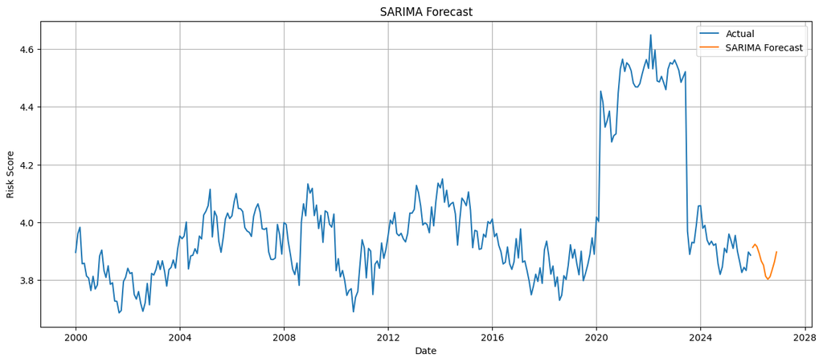

```python
plt.figure(figsize=(15,6))
plt.plot(
    trend_df["Date"],
    trend_df["Composite_Risk_Score"],
    label="Actual"
)
plt.plot(
    future_dates,
    sarima_forecast,
    label="SARIMA Forecast"
)
plt.title("SARIMA Forecast")
plt.xlabel("Date")
plt.ylabel("Risk Score")
plt.legend()
plt.grid(True)
plt.show()
```

# Forecast Accuracy Evaluation (MAE, RMSE, MAPE)

```python
train = ts[:-12]
test = ts[-12:]
```

```python
from statsmodels.tsa.holtwinters import ExponentialSmoothing

hw_eval = ExponentialSmoothing(
    train,
    trend="add",
    seasonal="add",
    seasonal_periods=12
).fit()

hw_pred = hw_eval.forecast(
    len(test)
)
```

```python
from statsmodels.tsa.arima.model import ARIMA

arima_eval = ARIMA(
    train,
    order=(1,1,1)
).fit()

arima_pred = arima_eval.forecast(
    len(test)
)
```

```python
from statsmodels.tsa.statespace.sarimax import SARIMAX

sarima_eval = SARIMAX(
    train,
    order=(1,1,1),
    seasonal_order=(1,1,1,12)
).fit(
    disp=False
)

sarima_pred = sarima_eval.forecast(
    len(test)
)
```

```python
from sklearn.metrics import (
    mean_absolute_error,
    mean_squared_error
)

import numpy as np
```

```python
def evaluate_forecast(
    actual,
    predicted
):
    mae = mean_absolute_error(
        actual,
        predicted
    )
    rmse = np.sqrt(
        mean_squared_error(
            actual,
            predicted
        )
    )
    mape = np.mean(
        np.abs((actual - predicted) / actual)) * 100
    return mae, rmse, mape
```

```python
hw_mae, hw_rmse, hw_mape = evaluate_forecast(
    test,
    hw_pred
)
arima_mae, arima_rmse, arima_mape = evaluate_forecast(
    test,
    arima_pred
)
sarima_mae, sarima_rmse, sarima_mape = evaluate_forecast(
    test,
    sarima_pred
)
```

```python
forecast_comparison = pd.DataFrame({

    "Model":[
        "Holt-Winters",
        "ARIMA",
        "SARIMA"
    ],
    "MAE":[
        hw_mae,
        arima_mae,
        sarima_mae
    ],
    "RMSE":[
        hw_rmse,
        arima_rmse,
        sarima_rmse
    ],
    "MAPE":[
        hw_mape,
        arima_mape,
        sarima_mape
    ]
})
forecast_comparison.round(4)
```

|  | Model | MAE | RMSE | MAPE |
| --- | --- | --- | --- | --- |
| 0 | Holt-Winters | 0.0290 | 0.0350 | 0.7440 |
| 1 | ARIMA | 0.0348 | 0.0435 | 0.8967 |
| 2 | SARIMA | 0.0280 | 0.0337 | 0.7164 |

# Prophet Forecasting

```python
from prophet import Prophet
```

```python
prophet_df = trend_df[["Date", "Composite_Risk_Score"]].copy()
prophet_df.columns = [
    "ds",
    "y"
]
```

```python
prophet_model = Prophet()
prophet_model.fit(prophet_df)
```

```
11:38:08 - cmdstanpy - INFO - Chain [1] start processing
11:38:09 - cmdstanpy - INFO - Chain [1] done processing
```

```
<prophet.forecaster.Prophet at 0x1a2815c3770>
```

```python
# 12 months future

future = prophet_model.make_future_dataframe(
    periods=12,
    freq="MS"
)
```

```python
forecast = prophet_model.predict(
    future
)
```

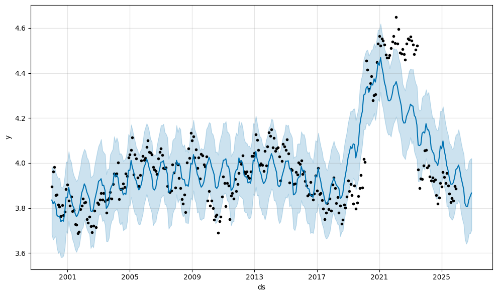

```python
fig = prophet_model.plot(forecast)
plt.show()
```

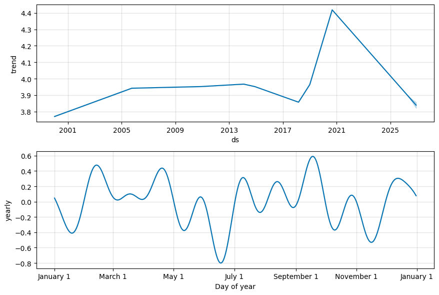

```python
fig2 = prophet_model.plot_components(forecast)
plt.show()
```

# VAR (Vector Auto Regression)

```python
var_df = trend_df.merge(
    df_scaled[
        [
            "Date",
            "GDP_Per_Capita_USD",
            "Inflation_Rate",
            "Interest_Rate",
            "Composite_Risk_Score"
        ]
    ],
    on="Date",
    how="left"
)
```

```python
var_final = var_df[
    [
        "GDP_Per_Capita_USD",
        "Inflation_Rate",
        "Interest_Rate",
        "Composite_Risk_Score_x"
    ]
].copy()
```

```python
var_final.columns = [
    "GDP",
    "Inflation",
    "Interest",
    "Risk"
]
```

```python
print(var_final.isna().sum())
```

```
GDP          0
Inflation    0
Interest     0
Risk         0
dtype: int64
```

```python
from statsmodels.tsa.api import VAR
```

```python
var_model = VAR(var_final)
var_fit = var_model.fit(maxlags=12)
```

```python
print(var_fit.summary())
```

```
  Summary of Regression Results
==================================
Model:                         VAR
Method:                        OLS
Date:           Mon, 15, Jun, 2026
Time:                     11:51:35
--------------------------------------------------------------------
No. of Equations:         4.00000    BIC:                   -12.3504
Nobs:                     148432.    HQIC:                  -12.3596
Log likelihood:           75302.1    FPE:                4.27169e-06
AIC:                     -12.3635    Det(Omega_mle):     4.26605e-06
--------------------------------------------------------------------
Results for equation GDP
================================================================================
                   coefficient       std. error           t-stat            prob
--------------------------------------------------------------------------------
const                -0.293169         0.052346           -5.601           0.000
L1.GDP                0.009699         0.002787            3.480           0.001
L1.Inflation         -0.003849         0.003701           -1.040           0.298
L1.Interest           0.005018         0.003848            1.304           0.192
L1.Risk               0.220713         0.812835            0.272           0.786
L2.GDP                0.012482         0.002787            4.478           0.000
L2.Inflation         -0.002686         0.003701           -0.726           0.468
L2.Interest           0.013176         0.003848            3.424           0.001
L2.Risk              -0.030235         1.149513           -0.026           0.979
L3.GDP                0.011151         0.002787            4.001           0.000
L3.Inflation         -0.001406         0.003701           -0.380           0.704
L3.Interest           0.005655         0.003849            1.469           0.142
L3.Risk              -0.606714         1.149504           -0.528           0.598
L4.GDP                0.018024         0.002787            6.467           0.000
L4.Inflation         -0.000702         0.003701           -0.190           0.850
L4.Interest           0.008563         0.003848            2.225           0.026
L4.Risk               1.527109         1.149483            1.329           0.184
L5.GDP                0.009826         0.002787            3.525           0.000
L5.Inflation         -0.001038         0.003701           -0.280           0.779
L5.Interest           0.006410         0.003848            1.665           0.096
L5.Risk              -1.081136         1.149491           -0.941           0.347
L6.GDP                0.016257         0.002787            5.832           0.000
L6.Inflation          0.004966         0.003701            1.342           0.180
L6.Interest          -0.003623         0.003848           -0.942           0.346
```

[output cut: 183 more lines]

```
L11.Inflation        -0.000004         0.000012           -0.348           0.728
L11.Interest         -0.000003         0.000012           -0.220           0.826
L11.Risk             -0.000070         0.003671           -0.019           0.985
L12.GDP               0.000008         0.000009            0.862           0.389
L12.Inflation        -0.000041         0.000012           -3.488           0.000
L12.Interest          0.000044         0.000012            3.591           0.000
L12.Risk             -0.000065         0.002596           -0.025           0.980
================================================================================

Correlation matrix of residuals
                  GDP  Inflation  Interest      Risk
GDP          1.000000  -0.260122 -0.364199 -0.001595
Inflation   -0.260122   1.000000  0.711079  0.003169
Interest    -0.364199   0.711079  1.000000  0.002027
Risk        -0.001595   0.003169  0.002027  1.000000
```

```python
var_forecast = var_fit.forecast(
    var_final.values[-var_fit.k_ar:],
    steps=12
)
```

```python
forecast_df = pd.DataFrame(
    var_forecast,
    columns=var_final.columns
)

forecast_df.head()
```

|  | GDP | Inflation | Interest | Risk |
| --- | --- | --- | --- | --- |
| 0 | 0.071692 | -0.021540 | 0.025930 | 3.886196 |
| 1 | 0.082145 | 0.000811 | -0.000093 | 3.886196 |
| 2 | 0.081897 | -0.012638 | 0.008982 | 3.886280 |
| 3 | 0.081224 | 0.001762 | -0.014680 | 3.886310 |
| 4 | 0.077735 | -0.016890 | 0.015884 | 3.886297 |

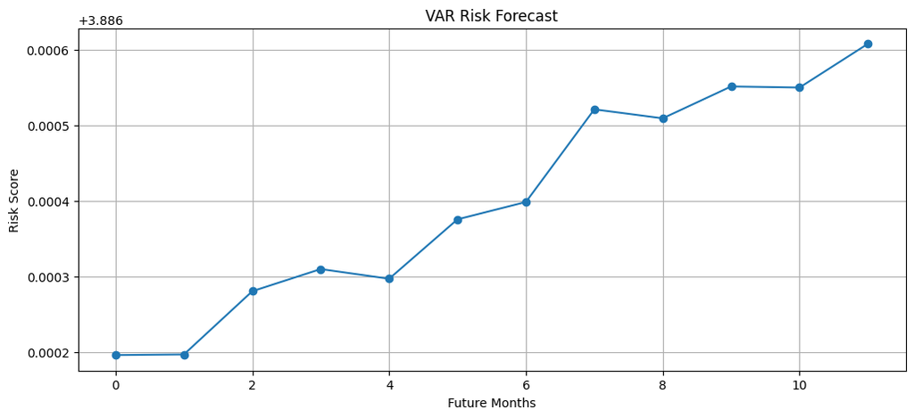

```python
plt.figure(figsize=(12,5))
plt.plot(
    forecast_df["Risk"],
    marker="o"
)
plt.title("VAR Risk Forecast")
plt.xlabel("Future Months")
plt.ylabel("Risk Score")
plt.grid(True)
plt.show()
```

# Final 3-Month Forecast

```python
forecast_3m = sarima_fit.forecast(steps=3)
forecast_3m
```

```
2026-01-01    3.913232
2026-02-01    3.924012
2026-03-01    3.915877
Freq: MS, Name: predicted_mean, dtype: float64
```

```python
future_3m_dates = pd.date_range(
    start=trend_df["Date"].max(),
    periods=4,
    freq="MS"
)[1:]
```

```python
forecast_3m_df = pd.DataFrame({
    "Date": future_3m_dates,
    "Forecast_Risk_Score": forecast_3m.values
})
forecast_3m_df
```

|  | Date | Forecast_Risk_Score |
| --- | --- | --- |
| 0 | 2026-01-01 | 3.913232 |
| 1 | 2026-02-01 | 3.924012 |
| 2 | 2026-03-01 | 3.915877 |

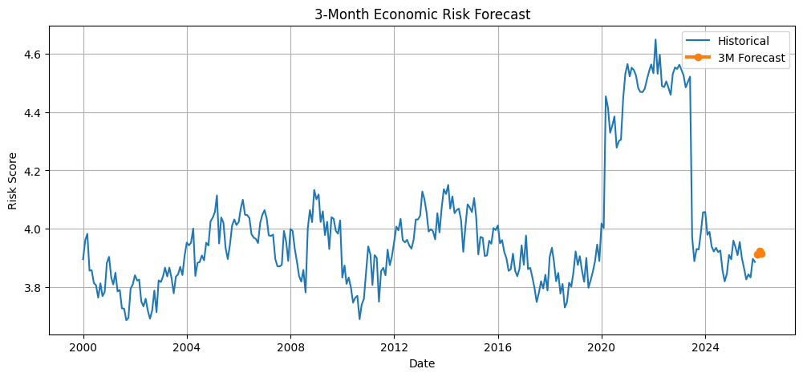

```python
plt.figure(figsize=(12,5))

plt.plot(
    trend_df["Date"],
    trend_df["Composite_Risk_Score"],
    label="Historical"
)
plt.plot(
    future_3m_dates,
    forecast_3m,
    marker="o",
    linewidth=3,
    label="3M Forecast"
)
plt.title("3-Month Economic Risk Forecast")
plt.xlabel("Date")
plt.ylabel("Risk Score")
plt.legend()
plt.grid(True)
plt.show()
```

## 3-Month Economic Risk Forecast

The SARIMA model was used to forecast economic risk for the next three months.

### Forecast Values

[output not shown]

### Key Findings

- Risk levels remain highly stable.
- No significant increase or decrease is expected.
- Forecast values stay close to the recent historical average.

### Business Insight

Economic conditions are expected to remain stable during the next quarter, with limited short-term risk volatility.

# Final 6-Month Forecast (Using SARIMA)

```python
forecast_6m = sarima_fit.forecast(steps=6)
forecast_6m
```

```
2026-01-01    3.913232
2026-02-01    3.924012
2026-03-01    3.915877
2026-04-01    3.893080
2026-05-01    3.866086
2026-06-01    3.851684
Freq: MS, Name: predicted_mean, dtype: float64
```

```python
future_6m_dates = pd.date_range(
    start=trend_df["Date"].max(),
    periods=7,
    freq="MS"
)[1:]
```

```python
forecast_6m_df = pd.DataFrame({
    "Date": future_6m_dates,
    "Forecast_Risk_Score": forecast_6m.values
})
forecast_6m_df
```

|  | Date | Forecast_Risk_Score |
| --- | --- | --- |
| 0 | 2026-01-01 | 3.913232 |
| 1 | 2026-02-01 | 3.924012 |
| 2 | 2026-03-01 | 3.915877 |
| 3 | 2026-04-01 | 3.893080 |
| 4 | 2026-05-01 | 3.866086 |
| 5 | 2026-06-01 | 3.851684 |

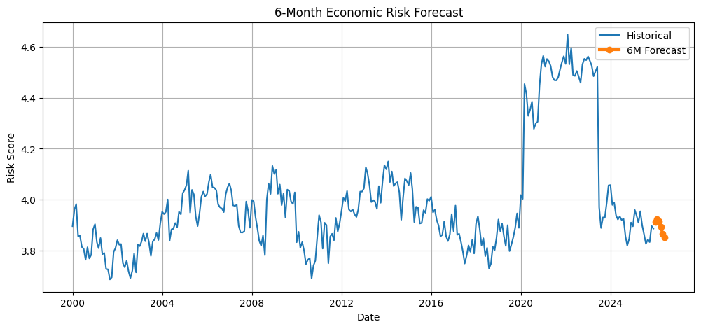

```python
plt.figure(figsize=(12,5))
plt.plot(
    trend_df["Date"],
    trend_df["Composite_Risk_Score"],
    label="Historical"
)
plt.plot(
    future_6m_dates,
    forecast_6m,
    marker="o",
    linewidth=3,
    label="6M Forecast"
)
plt.title("6-Month Economic Risk Forecast")
plt.xlabel("Date")
plt.ylabel("Risk Score")
plt.legend()
plt.grid(True)
plt.show()
```

## 6-Month Economic Risk Forecast

The SARIMA model was used to forecast economic risk over the next six months.

### Forecast Summary

- Risk levels remain generally stable.
- A slight downward trend is observed toward the end of the forecast horizon.
- No major economic risk shock is expected.

### Business Insight

The medium-term outlook suggests stable economic conditions with a modest improvement in risk levels over the next six months.

# 12-Month Forecast

```python
forecast_12m = sarima_fit.forecast(steps=12)

future_12m_dates = pd.date_range(
    start=trend_df["Date"].max(),
    periods=13,
    freq="MS"
)[1:]
forecast_12m_df = pd.DataFrame({
    "Date": future_12m_dates,
    "Forecast_Risk_Score": forecast_12m.values
})
forecast_12m_df
```

|  | Date | Forecast_Risk_Score |
| --- | --- | --- |
| 0 | 2026-01-01 | 3.913232 |
| 1 | 2026-02-01 | 3.924012 |
| 2 | 2026-03-01 | 3.915877 |
| 3 | 2026-04-01 | 3.893080 |
| 4 | 2026-05-01 | 3.866086 |
| 5 | 2026-06-01 | 3.851684 |
| 6 | 2026-07-01 | 3.813428 |
| 7 | 2026-08-01 | 3.802886 |
| 8 | 2026-09-01 | 3.811830 |
| 9 | 2026-10-01 | 3.835870 |
| 10 | 2026-11-01 | 3.862579 |
| 11 | 2026-12-01 | 3.897292 |

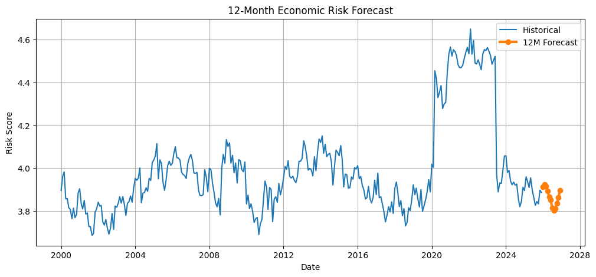

```python
plt.figure(figsize=(12,5))
plt.plot(
    trend_df["Date"],
    trend_df["Composite_Risk_Score"],
    label="Historical"
)
plt.plot(
    future_12m_dates,
    forecast_12m,
    marker="o",
    linewidth=3,
    label="12M Forecast"
)
plt.title("12-Month Economic Risk Forecast")
plt.xlabel("Date")
plt.ylabel("Risk Score")
plt.legend()
plt.grid(True)
plt.show()
```

### 12-Month Forecast

The SARIMA model forecasts stable economic risk levels over the next 12 months. Risk scores are expected to remain between 3.80 and 3.92, indicating no major economic shock. A slight mid-year decline is followed by gradual recovery, suggesting a stable long-term economic outlook.

```python
print(df_scaled.shape)
print(trend_df.shape)
print(forecast_12m_df.shape)
```

```
(148444, 87)
(312, 12)
(12, 2)
```

# Save Final And Clean Csv

```python
df_scaled.to_csv("economic_intelligence_final.csv",index=False)
```

```python
trend_df.to_csv("economic_risk_timeseries.csv",index=False)
```

```python
forecast_12m_df.to_csv("economic_risk_forecast_12m.csv",index=False)
```

```python
corr_df = df_scaled[
    [
        "GDP_Growth_Rate",
        "Inflation_Rate",
        "Unemployment_Rate",
        "Interest_Rate",
        "Composite_Risk_Score",
        "Economic_Health_Index"
    ]
].corr()

corr_df
```

|  | GDP_Growth_Rate | Inflation_Rate | Unemployment_Rate | Interest_Rate | Composite_Risk_Score | Economic_Health_Index |
| --- | --- | --- | --- | --- | --- | --- |
| GDP_Growth_Rate | 1.000000 | 0.014041 | -0.107911 | 0.018820 | -0.049440 | 0.228253 |
| Inflation_Rate | 0.014041 | 1.000000 | 0.124477 | 0.713543 | 0.534963 | -0.540418 |
| Unemployment_Rate | -0.107911 | 0.124477 | 1.000000 | 0.174661 | 0.529612 | -0.413732 |
| Interest_Rate | 0.018820 | 0.713543 | 0.174661 | 1.000000 | 0.491514 | -0.462372 |
| Composite_Risk_Score | -0.049440 | 0.534963 | 0.529612 | 0.491514 | 1.000000 | -0.512315 |
| Economic_Health_Index | 0.228253 | -0.540418 | -0.413732 | -0.462372 | -0.512315 | 1.000000 |

```python
corr_long = corr_df.reset_index().melt(
    id_vars="index",
    var_name="Metric2",
    value_name="Correlation"
)

corr_long.rename(
    columns={"index":"Metric1"},
    inplace=True
)

corr_long.head()
```

|  | Metric1 | Metric2 | Correlation |
| --- | --- | --- | --- |
| 0 | GDP_Growth_Rate | GDP_Growth_Rate | 1.000000 |
| 1 | Inflation_Rate | GDP_Growth_Rate | 0.014041 |
| 2 | Unemployment_Rate | GDP_Growth_Rate | -0.107911 |
| 3 | Interest_Rate | GDP_Growth_Rate | 0.018820 |
| 4 | Composite_Risk_Score | GDP_Growth_Rate | -0.049440 |

```python
corr_long.to_csv(
    "correlation_matrix.csv",
    index=False
)
```

# Final Project Conclusion

## Project Overview

This project developed a complete **Economic Intelligence & Forecasting System** using economic, financial, demographic, and risk-related indicators across multiple countries and time periods.

The primary objective was to analyze economic conditions, identify key risk drivers, segment economic profiles, build predictive models, and forecast future economic risk levels using Machine Learning and Time Series Analytics.

## Data Preparation & Feature Engineering

The dataset was cleaned, transformed, and enriched through extensive feature engineering.

Several business-oriented indicators were created, including:

- Economic Health Index
- Purchasing Power Stress
- Debt Pressure
- External Vulnerability
- Trade Dependency
- Inflation-Interest Gap
- High Risk Flag

These engineered features helped capture complex economic relationships and improved model performance.

## Exploratory Data Analysis (EDA)

Comprehensive exploratory analysis was conducted to understand economic patterns and relationships.

Key analyses included:

- Distribution Analysis
- Correlation Analysis
- Outlier Detection
- Economic Trend Analysis
- Country and Regional Comparisons

These analyses helped uncover hidden patterns and identify major economic drivers.

## Machine Learning Analysis

Multiple Machine Learning techniques were applied to gain deeper insights into economic risk.

### Regression Models

The following regression models were developed and evaluated:

- Linear Regression
- Ridge Regression
- Lasso Regression
- Random Forest Regression

Among them, **Random Forest Regression** achieved the strongest predictive performance.

### Classification Analysis

Classification techniques were used to categorize observations into different economic risk levels.

This helped identify high-risk economic conditions and improve decision-making.

### Clustering Analysis

K-Means Clustering was applied to group economies with similar characteristics.

This revealed distinct economic segments and behavioral patterns.

### Explainable AI

Feature Importance and SHAP Explainability were used to understand model behavior.

The most influential economic risk drivers were:

- Purchasing Power Stress
- Government Debt (% GDP)
- Gini Coefficient
- Corruption Index
- Unemployment Rate

These techniques improved model transparency and business interpretability.

## Time Series Analytics & Forecasting

A complete time series forecasting framework was developed.

The analysis included:

- Trend Analysis
- Seasonality Analysis
- Rolling Mean & Rolling Standard Deviation
- Stationarity Testing (ADF & KPSS)
- Time Series Decomposition
- ACF Analysis
- PACF Analysis

These techniques helped understand long-term economic behavior and prepare the data for forecasting.

## Forecasting Models

Multiple forecasting approaches were developed and compared:

- Moving Average
- Simple Exponential Smoothing (SES)
- Holt Method
- Holt-Winters Method
- ARIMA
- SARIMA
- Prophet
- VAR (Vector Auto Regression)

Forecast accuracy was evaluated using:

- MAE
- RMSE
- MAPE

## Best Forecasting Model

### Forecast Accuracy Comparison

| Model | MAE | RMSE | MAPE |
| --- | --- | --- | --- |
| Holt-Winters | 0.0290 | 0.0350 | 0.7440 |
| ARIMA | 0.0348 | 0.0435 | 0.8967 |
| SARIMA | 0.0280 | 0.0337 | 0.7164 |

Based on these results, SARIMA was selected as the final forecasting model.

## Forecast Results

Using the SARIMA model:

- 3-Month Forecast was generated
- 6-Month Forecast was generated
- 12-Month Forecast was generated

The forecasts indicate that economic risk levels are expected to remain generally stable, with only minor seasonal fluctuations and no major risk shock anticipated.

## Business Impact

This Economic Intelligence & Forecasting System can support:

- Economic Monitoring
- Risk Assessment
- Policy Evaluation
- Investment Analysis
- Strategic Planning
- Economic Forecasting

The combination of statistical analysis, machine learning, explainable AI, clustering techniques, and forecasting provides a comprehensive framework for understanding and predicting economic conditions.

## Final Conclusion

This project successfully developed an end-to-end Economic Intelligence & Forecasting System by integrating Data Analytics, Machine Learning, Explainable AI, Clustering Techniques, and Advanced Time Series Forecasting.

The results demonstrated that economic risk can be effectively analyzed, explained, segmented, and forecasted using data-driven methods. The SARIMA model emerged as the most accurate forecasting approach, while Explainable AI techniques identified the key economic factors influencing risk levels.

Overall, the project provides a robust decision-support framework that can help policymakers, analysts, investors, and organizations better understand economic conditions and make informed strategic decisions.

## Key Achievements

- Analyzed 148,444 economic records
- Processed 87 economic features
- Developed multiple Machine Learning models
- Implemented Explainable AI using SHAP
- Performed Economic Segmentation using Clustering
- Evaluated multiple forecasting models
- Identified SARIMA as the best forecasting model
- Generated 3-Month, 6-Month, and 12-Month forecasts
- Prepared data for Power BI Executive Dashboard